# Bayesian nonparametric inference for kinetic interacting particle systems: numerical experiments

Companion notebook to the paper *Bayesian nonparametric inference for kinetic interacting particle systems*.

*Luca Martucci, 2026.*

## 3.1 A Hermite–Fourier spectral solver

Setup and figure style, the phase-space grid and the Maxwellian-adapted Hermite basis, and the coefficient-hierarchy solver with Strang splitting.

```python
import os, time, math
import numpy as np
import matplotlib.pyplot as plt
from matplotlib.ticker import MaxNLocator
from cycler import cycler

from scipy.linalg import expm
from numpy.polynomial.hermite_e import hermeval

%config InlineBackend.figure_format = 'retina'

plt.rcParams.update({
    "font.family": "STIXGeneral", "mathtext.fontset": "stix",
    "font.size": 9, "axes.labelsize": 9, "axes.titlesize": 9, "legend.fontsize": 8,
    "xtick.labelsize": 8, "ytick.labelsize": 8,
    "axes.prop_cycle": cycler(color=['#0000CD', '#D62728', '#2CA02C', '#FF7F0E']),
    "axes.linewidth": 0.6, "lines.linewidth": 1.2, "lines.markersize": 4,
    "xtick.major.width": 0.6, "ytick.major.width": 0.6, "xtick.minor.width": 0.4,
    "ytick.minor.width": 0.4, "xtick.major.size": 3, "ytick.major.size": 3,
    "xtick.minor.size": 1.8, "ytick.minor.size": 1.8,
    "legend.fancybox": False, "legend.edgecolor": "0.8", "legend.framealpha": 0.9,
    "axes.grid": False, "figure.dpi": 150,
    "savefig.dpi": 600, "savefig.bbox": "standard", "pdf.fonttype": 42,
})

FIG_DIR   = "fig"
TEXTWIDTH = 16/2.54
os.makedirs(FIG_DIR, exist_ok=True)

def paper_figure(frac, height, **kw):
    """Figure of width frac*TEXTWIDTH and the given height (inches), laid out at its printed size;
    the paper includes it at width frac*\\textwidth, that is, unscaled."""
    return plt.subplots(figsize=(frac*TEXTWIDTH, height), layout="constrained", **kw)

def save_figure(fig, name):
    """Write fig/<name>.pdf (vector graphics; heatmaps embedded at 600 dpi) and display it."""
    fig.savefig(os.path.join(FIG_DIR, f"{name}.pdf"))
    plt.show()

def set_q_axis(ax, label=True):
    """Position axis on the torus T = R/2πZ ≃ [0, 2π)."""
    ax.set_xlim(0, 2*np.pi)
    ax.set_xticks(np.arange(5)*np.pi/2, ["$0$", r"$\pi/2$", r"$\pi$", r"$3\pi/2$", r"$2\pi$"])
    if label:
        ax.set_xlabel("$q$")

def heatmap(ax, Z, x, y, cmap, label, **kw):
    """Field Z[i, j] at the points (x[j], y[i]) of uniform grids, with a labelled colour bar."""
    dx, dy = x[1]-x[0], y[1]-y[0]
    im = ax.imshow(Z, origin='lower', aspect='auto', cmap=cmap, interpolation='bilinear',
                   extent=[x[0]-dx/2, x[-1]+dx/2, y[0]-dy/2, y[-1]+dy/2], **kw)
    cb = ax.figure.colorbar(im, ax=ax, pad=0.02, aspect=25)
    cb.set_label(label); cb.outline.set_linewidth(0.6)
    cb.ax.tick_params(width=0.6, length=2.5)
    ax.set_ylim(y[0], y[-1])
    return im

# ---- quadrature and interpolation on the periodic grid ----------------------------------------
# On the grid q_j = j*dq of T the rectangle rule is the quadrature of the torus, exact for
# trigonometric polynomials of degree < Nq/2 (a trapezoidal rule on q_0,...,q_{Nq-1} would omit the
# closing interval [q_{Nq-1}, 2π]); momentum integrals over a finite window use the trapezoidal rule.
trapezoid = getattr(np, "trapezoid", None) or np.trapz      # np.trapz was renamed in NumPy 2.0

def torus_integral(g, dq, axis=-1):
    return np.sum(g, axis=axis)*dq

def cosine_coefficients(W, q, K):
    """Cosine coefficients a_k = (1/π) ∫_T W(q) cos(kq) dq, k = 1, ..., K, of grid values W."""
    dq = q[1] - q[0]
    a = np.array([torus_integral(W*np.cos(kk*q), dq)/np.pi for kk in range(1, K+1)])
    return np.round(a, 13) + 0.0          # rounding off the floating-point noise of exact zeros

def trig_interp(values, x, axis=-1):
    """Trigonometric interpolant of values on the grid q_j = 2πj/Nq, evaluated at the points x
    (to draw the pseudo-spectral solutions smoothly)."""
    v = np.moveaxis(np.asarray(values, dtype=float), axis, -1)
    Nq = v.shape[-1]
    E = np.exp(1j*np.outer(np.fft.fftfreq(Nq, d=1/Nq), x))
    if Nq % 2 == 0:
        E[Nq//2] = np.cos(Nq//2*x)                          # symmetric Nyquist term
    return np.moveaxis(np.real((np.fft.fft(v, axis=-1)/Nq) @ E), -1, axis)

q_fine = np.linspace(0, 2*np.pi, 401)                       # plotting grid on [0, 2π]

# ---- plots shared by several experiments --------------------------------------------------------
def plot_reconstruction(ax, xi_samples, Phi_f, scale_, W_truth, rng_, n_draws=80, loc='upper left'):
    """Posterior draws (grey), the truth W_0 (solid) and the posterior mean (dashed) on q_fine;
    Phi_f is the cosine basis on q_fine and W_truth the truth on the solver grid."""
    for j in rng_.choice(len(xi_samples), n_draws, replace=False):
        ax.plot(q_fine, W_from_xi(xi_samples[j], Phi_f, scale_), color='0.5', alpha=0.15, lw=0.6)
    ax.plot(q_fine, trig_interp(W_truth, q_fine), color='C0', lw=1.4, label='$W_0$')
    ax.plot(q_fine, W_from_xi(xi_samples.mean(0), Phi_f, scale_), '--', color='C3', lw=1.4,
            label=r'$\widetilde{W}_N$')
    set_q_axis(ax); ax.legend(loc=loc)

def plot_coefficients(ax, mean, sd, truth, loc='best'):
    """Posterior mean ± one standard deviation of the cosine coefficients, against the truth."""
    pos = np.arange(1, len(mean)+1)
    ax.errorbar(pos, mean, yerr=sd, fmt='o', ms=3.5, capsize=2.5, elinewidth=1,
                label=r'posterior mean $\pm$ s.d.')
    ax.plot(pos, truth, 'rx', ms=6, mew=1.4, label='truth')
    ax.axhline(0, color='k', lw=0.4)
    ax.set_xticks(pos, [f"$a_{{{m}}}$" for m in pos])
    handles, labels = ax.get_legend_handles_labels()
    ax.legend(handles[::-1], labels[::-1], loc=loc)          # posterior first, then the truth

MODELS = (('rho', '(M1)', 'C3', 'o'), ('f', '(M2)', 'C0', 's'))   # key, name, colour and marker of each model

def plot_coefficients_models(ax, means, sds, truth, loc='best'):
    """Posterior mean ± one standard deviation of the cosine coefficients for both models, against the truth."""
    pos = np.arange(1, len(truth)+1)
    for (model, name, col, mk), off in zip(MODELS, (-0.13, 0.13)):
        ax.errorbar(pos + off, means[model], yerr=sds[model], fmt=mk, color=col, ms=3.2, capsize=2.2, elinewidth=1,
                    label=f'model {name}')
    ax.plot(pos, truth, 'kx', ms=6, mew=1.4, label='truth')
    ax.axhline(0, color='k', lw=0.4)
    ax.set_xticks(pos, [f"$a_{{{m}}}$" for m in pos]); ax.legend(loc=loc)

def plot_traces(ax, traces, burn, N, ylabel):
    """Log-likelihood traces of the chains of both models, with the burn-in and the plateau -N/2 marked. The vertical
    range is set by the traces after burn-in, two standard deviations sqrt(N/2) beyond them (plus headroom for the
    legend), so that the initial transients leave the plotted range."""
    for model, name, col, mk in MODELS:
        ax.plot(traces[model], lw=0.5, color=col, label=f'model {name}')
    ax.axvline(burn, color='k', ls=':', lw=1.2, label='burn-in')
    ax.axhline(-N/2, color='C2', ls='--', lw=1, label=r'$-N/2$')
    sd = np.sqrt(N/2)
    lo = min(min(tr[burn:].min() for tr in traces.values()), -N/2) - 2*sd
    hi = max(max(tr[burn:].max() for tr in traces.values()), -N/2) + 2*sd
    ax.set_ylim(lo, hi + 0.35*(hi - lo))              # headroom above the traces for the legend
    ax.set_xlabel("iteration"); ax.set_ylabel(ylabel)
    for line in ax.legend(loc='upper center', ncol=2).get_lines():
        line.set_linewidth(1.4)                       # legend handles thicker than the traces

def plot_sweep_models(sweeps, W_truth, name):
    """Truncation sweep for both models: L^2 error of the posterior mean against the truncation level K (left); the
    range of the posterior means over K (bands) and the posterior mean at the largest K (lines), against the truth (right)."""
    fig, ax = paper_figure(0.95, 2.2, ncols=2, gridspec_kw={'width_ratios': [1, 1.6]})
    for model, name_, col, mk in MODELS:
        sweep = sweeps[model]; Ks = list(sweep)
        ax[0].plot(Ks, [sweep[K]['errW'] for K in Ks], mk + '-', ms=3.5, color=col, label=f'model {name_}')
        means = np.array([build_basis_cos(q_fine, K) @ (sweep[K]['scale']*sweep[K]['post'].mean(0)) for K in Ks])
        ax[1].fill_between(q_fine, means.min(0), means.max(0), color=col, alpha=0.3, lw=0)
        ax[1].plot(q_fine, means[-1], color=col, lw=1.1, label=f'model {name_}')
    ax[0].set_xticks(Ks); ax[0].set_ylim(bottom=0); ax[0].legend(loc='lower right')
    ax[0].set_xlabel("truncation level $K$"); ax[0].set_ylabel(r"$\|\widetilde{W}_N-W_0\|_{L^2}$")
    ax[1].plot(q_fine, trig_interp(W_truth, q_fine), 'k', lw=1.6, label='$W_0$')
    set_q_axis(ax[1]); ax[1].legend(loc='upper left')
    save_figure(fig, name)

def gauss(x, m, sd):
    return np.exp(-0.5*((x-m)/sd)**2)/(sd*np.sqrt(2*np.pi))

def plot_marginals(prior_sd, posts, truth, name=None):
    """Prior (filled) against the linearised posterior marginals of a_1, ..., a_12 for both models, with the truth
    (dashed); each panel title gives the shrinkages S_k of models (M1) and (M2)."""
    fig, axes = paper_figure(0.95, 3.6, nrows=3, ncols=4)
    for m, ax in enumerate(axes.ravel()):
        lim = 3*prior_sd[m]
        xg = np.concatenate([np.linspace(-lim, lim, 801)]
                            + [posts[model]['mean'][m] + np.linspace(-6, 6, 801)*posts[model]['sd'][m] for model in posts])
        xg = np.sort(xg[np.abs(xg) <= lim])
        ax.fill_between(xg, gauss(xg, 0, prior_sd[m]), color='#cbb8e0', alpha=0.8, lw=0, label='prior')
        for model, name_, col, mk in MODELS:
            ax.plot(xg, gauss(xg, posts[model]['mean'][m], posts[model]['sd'][m]), color=col, lw=1.2,
                    ls='-' if model == 'rho' else '--', label=f'model {name_}')
        ax.axvline(truth[m], color='k', ls=':', lw=0.9, label='truth')
        ax.set_xlim(-lim, lim); ax.set_ylim(bottom=0); ax.set_yticks([])
        ax.xaxis.set_major_locator(MaxNLocator(nbins=4, symmetric=True))
        ax.set_title(rf"$a_{{{m+1}}}$:  {posts['rho']['shrink'][m]:.2f},  {posts['f']['shrink'][m]:.2f}", fontsize=8)
        if m == 0:
            ax.legend(fontsize=6.5, loc='upper right', handlelength=1.4)
    if name:
        save_figure(fig, name)
    else:
        plt.show()

rng_global = np.random.default_rng(0)
```

```python
def make_grid(Nq, L=2*np.pi):
    q  = np.arange(Nq) * (L / Nq)
    dq = L / Nq
    k  = 2*np.pi * np.fft.fftfreq(Nq, d=dq)
    return q, dq, k

def hermite_eval(NH, p, beta):
    # B[i, n] = e_n(p_i) = sqrt(beta)/sqrt(2 pi n!) He_n(sqrt(beta) p) exp(-beta p^2 / 2)
    xi    = np.sqrt(beta) * np.atleast_1d(p)
    gauss = np.sqrt(beta) / np.sqrt(2*np.pi) * np.exp(-0.5*xi**2)
    B = np.zeros((len(xi), NH))
    for n in range(NH):
        c = np.zeros(n+1); c[n] = 1.0
        B[:, n] = hermeval(xi, c) / np.sqrt(float(math.factorial(n))) * gauss
    return B

# quick checks of the two defining properties of e_n
q, dq, k = make_grid(48)
pp = np.linspace(-12, 12, 4000); beta_chk = 1.0
B = hermite_eval(6, pp, beta_chk)
ints = trapezoid(B, pp, axis=0)                 # should be (1,0,0,0,0,0)
print("int e_n dp      =", np.round(ints, 4))
print("max |e_0 - M|   =", np.max(np.abs(B[:,0] -
      np.sqrt(beta_chk/(2*np.pi))*np.exp(-0.5*beta_chk*pp**2))))
```

```
int e_n dp      = [ 1. -0. -0. -0.  0. -0.]
max |e_0 - M|   = 0.0
```

```python
def build_linear_exponentials(k, NH, gamma, beta, dt):
    Ehalf = np.empty((len(k), NH, NH), dtype=complex)
    Efull = np.empty((len(k), NH, NH), dtype=complex)
    n = np.arange(NH)
    for ik, kk in enumerate(k):
        L = np.zeros((NH, NH), dtype=complex)
        L[n, n] = -gamma * n                                  # friction (diagonal)
        for m in range(NH):                                   # streaming (tridiagonal)
            if m-1 >= 0:  L[m, m-1] += -(1j*kk/np.sqrt(beta)) * np.sqrt(m)
            if m+1 < NH:  L[m, m+1] += -(1j*kk/np.sqrt(beta)) * np.sqrt(m+1)
        Ehalf[ik] = expm(0.5*dt*L)
        Efull[ik] = expm(dt*L)
    return Ehalf, Efull

def force_kick(c, A, tau, beta):
    # exact exponential of the nilpotent force generator (N c)_n = sqrt(beta n) A c_{n-1}
    NH = c.shape[0]
    sb  = np.sqrt(beta * np.arange(NH))
    out, term = c.copy(), c.copy()
    for j in range(1, NH):                                    # nilpotent => finite sum
        new = np.zeros_like(term)
        new[1:] = sb[1:, None] * A[None, :] * term[:-1]
        term = new * (tau / j)
        out += term
        if not np.any(term): break
    return out

class KineticVFP:
    def __init__(self, q, dq, k, NH, gamma, beta, dt, V):
        self.q, self.dq, self.k = q, dq, k
        self.NH, self.gamma, self.beta, self.dt = NH, gamma, beta, dt
        self.dV = np.real(np.fft.ifft(1j*k*np.fft.fft(V)))                # dV/dq
        self.Ehalf, self.Efull = build_linear_exponentials(k, NH, gamma, beta, dt)

    def force_field(self, rho, W):
        Wconv_hat = self.dq * np.fft.fft(W) * np.fft.fft(rho)            # W * rho
        dWconv    = np.real(np.fft.ifft(1j*self.k*Wconv_hat))
        return -self.dV - dWconv                                          # A = -d/dq (V + W*rho)

    def linear_step(self, c, E):
        chat = np.fft.fft(c, axis=1)                                      # (NH, Nq)
        chat = np.einsum('kmn,nk->mk', E, chat)                           # apply E_k per wavenumber
        return np.real(np.fft.ifft(chat, axis=1))

    def step(self, c, W):
        dt = self.dt
        c = force_kick(c, self.force_field(c[0], W), dt/2, self.beta)
        c = self.linear_step(c, self.Efull)
        c = force_kick(c, self.force_field(c[0], W), dt/2, self.beta)
        return c

    def solve(self, W, c_init, Nt, save_every=1):
        c = c_init.copy()
        saved, times = [c.copy()], [0.0]
        for nstep in range(Nt):
            c = self.step(c, W)
            if (nstep+1) % save_every == 0:
                saved.append(c.copy()); times.append((nstep+1)*self.dt)
        return np.array(times), np.array(saved)        # saved: (Ns, NH, Nq)
```

### 3.1.3 Validation of the solver

Five checks: (1) the force-free density modes against their closed form, which tests streaming, friction and the Hermite truncation together; (2)–(3) mass conservation, equilibrium stationarity and $O(\Delta t^2)$ consistency; (4) convergence in the number $N_H$ of Hermite modes with the force switched on, and the gap between the solver that generates the data and the solver of the likelihood; (5) a particle cross-check for the ground truth $W_0$.

```python
# (1) force-free density modes against their closed form. With V = W = 0 and the local Maxwellian
# initial state rho0 x M_beta, the Fourier mode k of the density evolves as
#     rho_hat(t,k) = rho_hat(0,k) exp(-k^2 (gamma t - 1 + exp(-gamma t)) / (beta gamma^2)),
# the characteristic function of the time integral of a stationary Ornstein-Uhlenbeck velocity.
# Without force the solver applies the exact exponentials of the truncated blocks L_k, so the error
# below is the error of the Hermite truncation alone.
Nq, NH = 48, 14
gamma, beta = 1.0, 1.0
q, dq, k = make_grid(Nq)
rho_test = (1 + 0.2*np.cos(q) + 0.2*np.cos(2*q) + 0.2*np.cos(3*q))/(2*np.pi)
print("Force-free density modes, max over t <= 2 of |error| / |initial amplitude|:")
for NH_test in (14, 20):
    s_free = KineticVFP(q, dq, k, NH_test, gamma, beta, dt=0.02, V=np.zeros(Nq))
    c_free = np.zeros((NH_test, Nq)); c_free[0] = rho_test
    tt, sol_free = s_free.solve(np.zeros(Nq), c_free, Nt=100, save_every=1)
    rho_hat = np.fft.fft(sol_free[:, 0, :], axis=1)/Nq
    errs = []
    for kk in (1, 2, 3):
        exact = rho_hat[0, kk]*np.exp(-kk**2*(gamma*tt - 1 + np.exp(-gamma*tt))/(beta*gamma**2))
        errs.append(np.max(np.abs(rho_hat[:, kk] - exact))/np.abs(rho_hat[0, kk]))
    print(f"  N_H={NH_test}:  k=1: {errs[0]:.1e}   k=2: {errs[1]:.1e}   k=3: {errs[2]:.1e}")
```

```
Force-free density modes, max over t <= 2 of |error| / |initial amplitude|:
  N_H=14:  k=1: 4.8e-15   k=2: 4.9e-09   k=3: 1.1e-05
  N_H=20:  k=1: 5.5e-15   k=2: 3.1e-15   k=3: 1.0e-09
```

```python
# (2)+(3) mass conservation, equilibrium stationarity, O(dt^2)
V  = -np.cos(q)
W  = -np.cos(q) + 0.5*np.cos(2*q)

# self-consistent McKean-Vlasov equilibrium density via Picard iteration
rho = np.ones(Nq) / (2*np.pi)
for _ in range(500):
    Wconv = np.real(np.fft.ifft(dq*np.fft.fft(W)*np.fft.fft(rho)))
    new   = np.exp(-beta*(V + Wconv)); new /= new.sum()*dq
    if np.max(np.abs(new-rho)) < 1e-14: break
    rho = new
c_eq = np.zeros((NH, Nq)); c_eq[0] = rho

solver = KineticVFP(q, dq, k, NH, gamma, beta, dt=0.02, V=V)
rho0 = 1 + 0.6*np.sin(q) + 0.3*np.cos(2*q); rho0 = np.clip(rho0, 1e-3, None); rho0 /= rho0.sum()*dq
c_init = np.zeros((NH, Nq)); c_init[0] = rho0
times, sol = solver.solve(W, c_init, Nt=100, save_every=10)
print("Mass over time:", np.round(sol[:, 0, :].sum(axis=1)*dq, 12))

print("\nEquilibrium drift vs dt (Strang 2nd order):")
for dt in [0.08, 0.04, 0.02, 0.01]:
    s = KineticVFP(q, dq, k, NH, gamma, beta, dt, V)
    _, traj = s.solve(W, c_eq, Nt=int(1.6/dt), save_every=10)
    print(f"  dt={dt:.3f}  max|c(t)-c_eq| = {np.max(np.abs(traj-c_eq[None])):.3e}")
```

```
Mass over time: [1. 1. 1. 1. 1. 1. 1. 1. 1. 1. 1.]

Equilibrium drift vs dt (Strang 2nd order):
  dt=0.080  max|c(t)-c_eq| = 4.772e-04
  dt=0.040  max|c(t)-c_eq| = 1.194e-04
  dt=0.020  max|c(t)-c_eq| = 2.985e-05
```

```
  dt=0.010  max|c(t)-c_eq| = 7.463e-06
```

```python
# (4) convergence in N_H with the force switched on: the trajectory of Section 3.2.1 (W_0, rho0 x M_beta)
# at N_H = 10, 14, 20, 30 against N_H = 40, all with dt = 0.01, on the momentum window |p| <= 3.5 of
# the observations; then the gap between the solver that generates the data (N_H = 20, dt = 0.01)
# and the solver of the likelihood (N_H = 14, dt = 0.02), against the noise levels of Section 3.2.1.
W_chk = -np.cos(q) + 0.5*np.cos(2*q) - 0.25*np.cos(3*q)       # the ground truth W_0 of Section 3.2.1
P_win = np.linspace(-3.5, 3.5, 141)

def trajectory(NH_, dt_):
    s_ = KineticVFP(q, dq, k, NH_, gamma, beta, dt_, V)
    c_ = np.zeros((NH_, Nq)); c_[0] = rho0
    _, sol_ = s_.solve(W_chk, c_, Nt=int(round(2.0/dt_)), save_every=int(round(0.02/dt_)))
    return sol_                                                   # snapshots every 0.02

def f_window(sol_):
    return np.einsum('tnq,pn->tqp', sol_, hermite_eval(sol_.shape[1], P_win, beta))

ref = trajectory(40, 0.01); f_ref = f_window(ref)
print("Convergence in N_H (dt = 0.01, force on), against N_H = 40:")
for NH_ in (10, 14, 20, 30):
    s_ = trajectory(NH_, 0.01)
    print(f"  N_H={NH_:2d}:  max|rho - rho_ref| = {np.max(np.abs(s_[:, 0]-ref[:, 0])):.1e}   "
          f"max|f - f_ref| = {np.max(np.abs(f_window(s_)-f_ref)):.1e}")
data_sol, lik_sol = trajectory(20, 0.01), trajectory(14, 0.02)
d_rho = data_sol[1:, 0] - lik_sol[1:, 0]
d_f = f_window(data_sol)[1:] - f_window(lik_sol)[1:]
print(f"data solver (N_H=20, dt=0.01) against likelihood solver (N_H=14, dt=0.02):")
print(f"  max|d rho| = {np.abs(d_rho).max():.1e} (rms {np.sqrt(np.mean(d_rho**2)):.1e}),  "
      f"max|d f| = {np.abs(d_f).max():.1e} (rms {np.sqrt(np.mean(d_f**2)):.1e})")
```

```
Convergence in N_H (dt = 0.01, force on), against N_H = 40:
  N_H=10:  max|rho - rho_ref| = 1.8e-04   max|f - f_ref| = 4.1e-04
  N_H=14:  max|rho - rho_ref| = 1.3e-05   max|f - f_ref| = 6.6e-05
```

```
  N_H=20:  max|rho - rho_ref| = 3.0e-07   max|f - f_ref| = 5.1e-06
  N_H=30:  max|rho - rho_ref| = 7.5e-10   max|f - f_ref| = 8.6e-08
```

```
data solver (N_H=20, dt=0.01) against likelihood solver (N_H=14, dt=0.02):
  max|d rho| = 1.6e-05 (rms 4.9e-06),  max|d f| = 6.1e-05 (rms 8.4e-06)
```

```
||rho_hist(T) - rho_PDE(T)||_L2 = 0.0090   (density scale 1/(2 pi) = 0.159; root-mean-square relative discrepancy 2.3%)
```

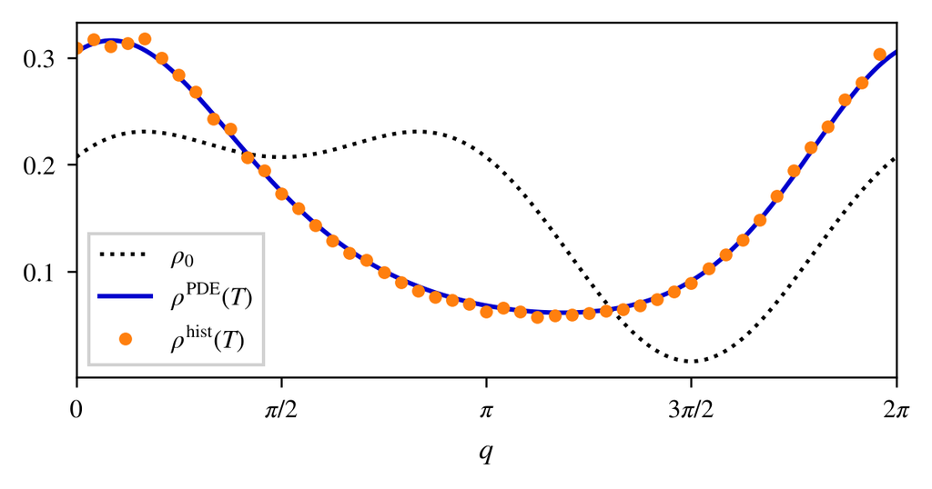

```python
# (5) particle cross-check, up to the horizon T = 2, for the ground truth W_0 and the initial state rho0 x M_beta of
# Section 3.2.1: the particle system with the mean-field force evaluated on the histogram of the particles at the
# grid points (nearest-grid-point assignment)
dt = 0.01
solver = KineticVFP(q, dq, k, NH, gamma, beta, dt, V)
T = 2.0; Nt = int(round(T/dt))
_, sol = solver.solve(W_chk, c_init, Nt, save_every=Nt)
rho_pde = sol[-1, 0, :]

# Histogram bins centred at the grid points, [q_j - dq/2, q_j + dq/2): the value of bin j estimates
# the density at q_j, where the convolution is evaluated and the spectral density is compared, and
# each particle feels the mean-field force at its nearest grid point.
def grid_bin(x):
    return np.floor(((x + dq/2) % (2*np.pi))/dq).astype(int) % Nq

def histogram_density(x):
    return np.bincount(grid_bin(x), minlength=Nq)/(len(x)*dq)

rng = np.random.default_rng(0)
n_part = 200_000
cdf = np.cumsum(rho0*dq); cdf /= cdf[-1]
qj = np.interp(rng.random(n_part), cdf, q)        # q0 ~ rho0
pj = rng.standard_normal(n_part) / np.sqrt(beta)  # p0 ~ Maxwellian
W_hat = np.fft.fft(W_chk)
for _ in range(Nt):
    hist    = histogram_density(qj)
    dWconv  = np.real(np.fft.ifft(1j*k*dq*W_hat*np.fft.fft(hist)))
    force   = -np.sin(qj) - dWconv[grid_bin(qj)]  # -dV - d(W*rho),  V=-cos
    pj += dt*force - gamma*pj*dt + np.sqrt(2*gamma/beta*dt)*rng.standard_normal(n_part)
    qj  = (qj + pj*dt) % (2*np.pi)
hist_T = histogram_density(qj)
errL2  = np.sqrt(torus_integral((hist_T - rho_pde)**2, dq))
print(f"||rho_hist(T) - rho_PDE(T)||_L2 = {errL2:.4f}   (density scale 1/(2 pi) = {1/(2*np.pi):.3f}; "
      f"root-mean-square relative discrepancy {np.sqrt(np.mean((hist_T - rho_pde)**2))*2*np.pi:.1%})")

fig, ax = paper_figure(0.62, 2.0)
ax.plot(q_fine, trig_interp(rho0, q_fine), 'k:', lw=1.2, label=r'$\rho_0$')
ax.plot(q_fine, trig_interp(rho_pde, q_fine), color='C0', lw=1.4, label=r'$\rho^{\mathrm{PDE}}(T)$')
ax.plot(q, hist_T, 'o', color='C3', ms=3, label=r'$\rho^{\mathrm{hist}}(T)$')
set_q_axis(ax); ax.legend()
save_figure(fig, "ips_crosscheck")
```

### 3.1.4 Hypocoercivity in the discretised generator

```python
# Spectrum of the linear streaming+friction operator L_k, wavenumber by wavenumber: the least-damped rates of the
# truncated blocks against the exact values k^2/(beta gamma), and the condition number of the leading eigenvalue.
NH_spec, gamma_spec, beta_spec = 14, 1.0, 1.0

def Lk_matrix(kk, NH, gamma, beta):
    L = np.zeros((NH, NH), dtype=complex)
    for m in range(NH):
        L[m, m] = -gamma * m                                       # friction (diagonal)
        if m-1 >= 0:  L[m, m-1] += -(1j*kk/np.sqrt(beta)) * np.sqrt(m)     # streaming
        if m+1 < NH:  L[m, m+1] += -(1j*kk/np.sqrt(beta)) * np.sqrt(m+1)
    return L

k_scan = np.arange(0, 9)
slowest = np.array([np.linalg.eigvals(Lk_matrix(kk, NH_spec, gamma_spec, beta_spec)).real.max()
                    for kk in k_scan])
print("k                              :", k_scan)
print("least-damped rate, N_H = 14    :", np.round(-slowest, 3))
print("exact rate k^2/(beta gamma)    :", k_scan**2/(beta_spec*gamma_spec))
for NH_chk in (20, 40):
    rates = [-np.linalg.eigvals(Lk_matrix(kk, NH_chk, gamma_spec, beta_spec)).real.max() for kk in (1, 2, 3)]
    print(f"N_H={NH_chk}: least-damped rates at k=1,2,3 = " + ", ".join(f"{r:.3f}" for r in rates))
print("condition number e^{2k^2/(gamma^2 beta)} of the leading eigenvalue, k=1,...,4:",
      ", ".join(f"{np.exp(2*kk**2/(gamma_spec**2*beta_spec)):.1e}" for kk in (1, 2, 3, 4)))
```

```
k                              : [0 1 2 3 4 5 6 7 8]
least-damped rate, N_H = 14    : [0.    1.    3.674 4.112 4.228 4.278 4.304 4.32  4.33 ]
exact rate k^2/(beta gamma)    : [ 0.  1.  4.  9. 16. 25. 36. 49. 64.]
N_H=20: least-damped rates at k=1,2,3 = 1.000, 4.001, 5.810
N_H=40: least-damped rates at k=1,2,3 = 1.000, 4.000, 9.000
condition number e^{2k^2/(gamma^2 beta)} of the leading eigenvalue, k=1,...,4: 7.4e+00, 3.0e+03, 6.6e+07, 7.9e+13
```

## 3.2 The statistical experiment

Ground truth $W_0$, the initial state $\phi=\rho_0\otimes M_\beta$, and the observation designs of both measurement models, with the noise calibrated to a common noise-to-signal ratio; the data are generated at a finer resolution than the solver of the likelihood, to avoid the inverse crime.

```python
def generate_truth(seed=0, W_true=None, Nq=48, NH_hi=20, gamma=1.0, beta=1.0, T=2.0, dt_hi=0.01):
    q, dq, k = make_grid(Nq); V = -np.cos(q)
    if W_true is None:
        W_true = -np.cos(q) + 0.5*np.cos(2*q) - 0.25*np.cos(3*q)
    rho0 = 1 + 0.6*np.sin(q) + 0.3*np.cos(2*q); rho0 = np.clip(rho0, 1e-3, None); rho0 /= rho0.sum()*dq
    c_init = np.zeros((NH_hi, Nq)); c_init[0] = rho0
    solver_hi = KineticVFP(q, dq, k, NH_hi, gamma, beta, dt_hi, V)
    times, sol = solver_hi.solve(W_true, c_init, Nt=int(T/dt_hi), save_every=2)       # snapshots every 0.02
    return dict(q=q, dq=dq, k=k, T=T, gamma=gamma, beta=beta, V=V, rho0=rho0,
                W_true=W_true, times=times, sol_hi=sol, NH_hi=NH_hi)

truth = generate_truth(0)
q, dq, k = truth['q'], truth['dq'], truth['k']

# shared observation design: same (t_i, q_i) for both models
rng = np.random.default_rng(0)
N_obs = 3000
t_idx = rng.integers(1, len(truth['times']), N_obs)   # exclude t=0
q_idx = rng.integers(0, len(q), N_obs)

# --- f-data: also draw momenta p_i and evaluate the full state ---
p_obs = rng.uniform(-3.5, 3.5, N_obs)
B_hi  = hermite_eval(truth['NH_hi'], p_obs, truth['beta'])
f_clean = np.einsum('in,in->i', truth['sol_hi'][t_idx, :, q_idx], B_hi)

# --- rho-data: just read c_0 at the same (t_i, q_i); no momentum ---
rho_clean = truth['sol_hi'][t_idx, 0, q_idx]

# common noise-to-signal ratio (noise s.d. / signal s.d.) for the two observables
noise_to_signal = 0.15
sig_f   = noise_to_signal*f_clean.std()
sig_rho = noise_to_signal*rho_clean.std()
Y_f   = f_clean   + sig_f  *rng.standard_normal(N_obs)
Y_rho = rho_clean + sig_rho*rng.standard_normal(N_obs)

print(f"snapshots = {len(truth['times'])} (every 0.02 up to T = {truth['T']}),  N_obs = {N_obs}")
print(f"f  :  signal std = {f_clean.std():.4f},  sigma = {sig_f:.4f},  observed values in [{f_clean.min():.3f}, {f_clean.max():.3f}]")
print(f"rho:  signal std = {rho_clean.std():.4f},  sigma = {sig_rho:.4f}")
print(f"mass at t=0 = {truth['sol_hi'][0,0].sum()*dq:.10f},  at t=T = {truth['sol_hi'][-1,0].sum()*dq:.10f}")
```

```
snapshots = 101 (every 0.02 up to T = 2.0),  N_obs = 3000
f  :  signal std = 0.0269,  sigma = 0.0040,  observed values in [0.000, 0.113]
rho:  signal std = 0.0734,  sigma = 0.0110
mass at t=0 = 1.0000000000,  at t=T = 1.0000000000
```

### 3.2.1 Ground truth and synthetic data

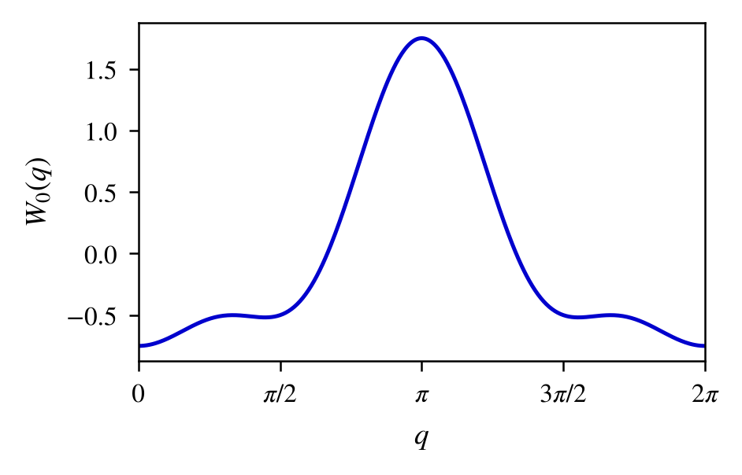

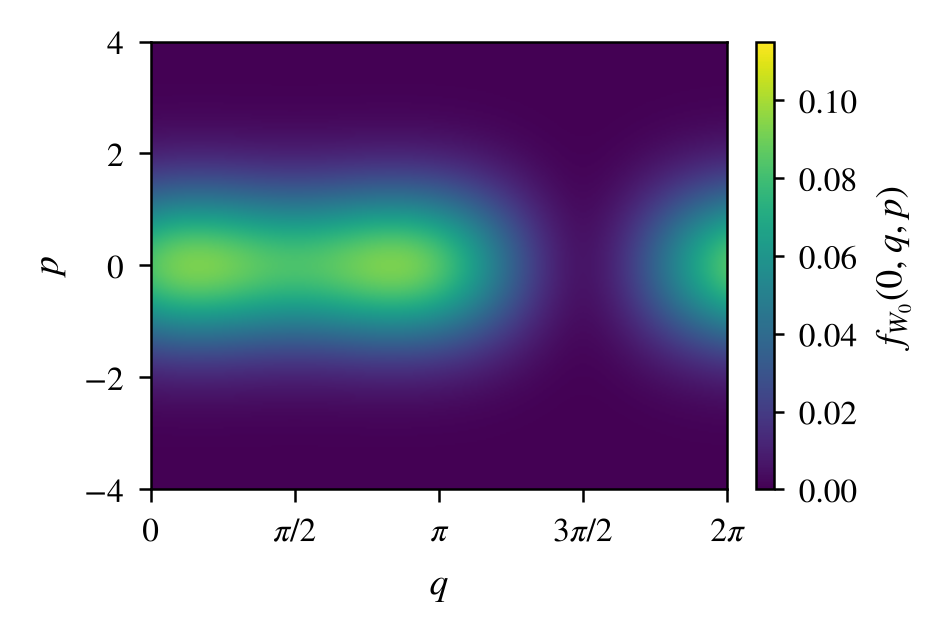

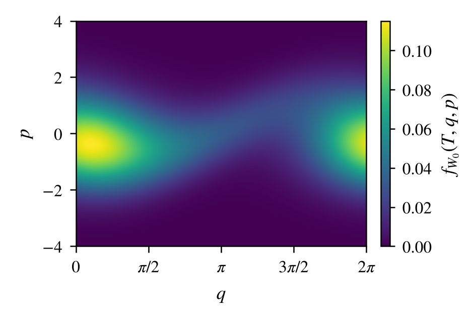

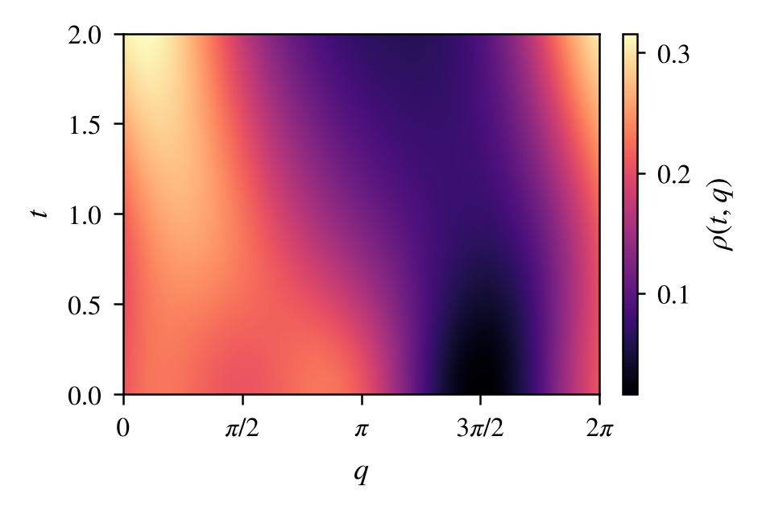

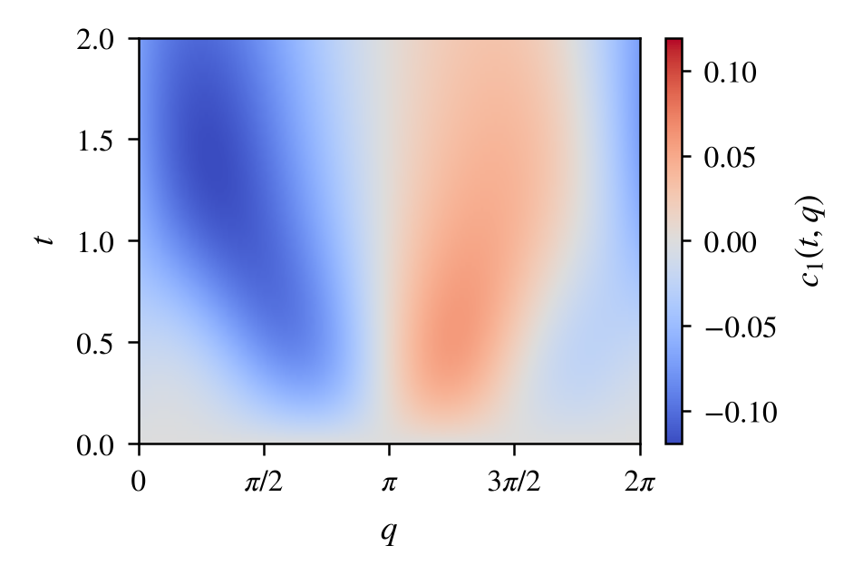

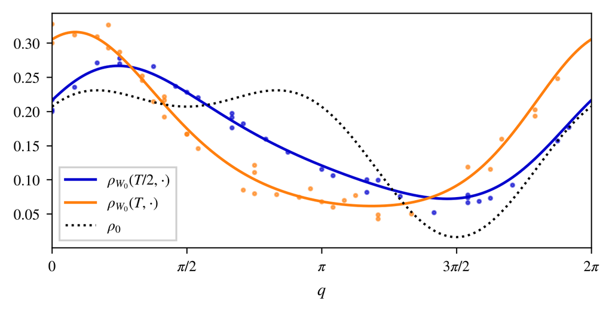

```python
ts = truth['times']
P_img = np.linspace(-4, 4, 241)                    # momentum and position grids for the heatmaps
q_img = np.linspace(0, 2*np.pi, 385)
Bp = hermite_eval(truth['NH_hi'], P_img, truth['beta'])

def phase_density(coeff_q):                        # f(q,p) = sum_n c_n(q) e_n(p) on q_img x P_img
    return trig_interp(coeff_q, q_img, axis=1).T @ Bp.T

# ground truth W_0
fig, ax = paper_figure(0.48, 1.9)
ax.plot(q_fine, trig_interp(truth['W_true'], q_fine), color='C0')
set_q_axis(ax); ax.set_ylabel("$W_0(q)$")
plt.show()

# phase-space density at t = 0 and t = T, on a common colour scale
f0 = phase_density(truth['sol_hi'][0])
fT = phase_density(truth['sol_hi'][-1])
f_max = max(f0.max(), fT.max())
for name, f_qp, label in [("f_initial", f0, "$f_{W_0}(0,q,p)$"), ("f_final", fT, "$f_{W_0}(T,q,p)$")]:
    fig, ax = paper_figure(0.48, 2.0)
    heatmap(ax, f_qp.T, q_img, P_img, 'viridis', label, vmin=0, vmax=f_max)
    set_q_axis(ax); ax.set_ylabel("$p$")
    save_figure(fig, name)

# density rho(t,q) = c_0(t,q), observed in model (M1), and first Hermite coefficient c_1(t,q), the current (beta = 1)
rho_tq = trig_interp(truth['sol_hi'][:, 0, :], q_img, axis=1)
c1_tq  = trig_interp(truth['sol_hi'][:, 1, :], q_img, axis=1)
fig, ax = paper_figure(0.48, 2.0)
heatmap(ax, rho_tq, q_img, ts, 'magma', r"$\rho(t,q)$")
set_q_axis(ax); ax.set_ylabel("$t$")
save_figure(fig, "rho_heatmap")

c1_max = np.abs(c1_tq).max()                       # colour scale centred at zero
fig, ax = paper_figure(0.48, 2.0)
heatmap(ax, c1_tq, q_img, ts, 'coolwarm', r"$c_1(t,q)$", vmin=-c1_max, vmax=c1_max)
set_q_axis(ax); ax.set_ylabel("$t$")
save_figure(fig, "c1_heatmap")

# density snapshots with the noisy rho-observations falling on them
fig, ax = paper_figure(0.7, 2.2)
for tt, c, label in [(truth['T']/2, 'C0', r'$\rho_{W_0}(T/2,{\cdot})$'), (truth['T'], 'C3', r'$\rho_{W_0}(T,{\cdot})$')]:
    it = int(np.argmin(np.abs(truth['times']-tt)))
    ax.plot(q_fine, trig_interp(truth['sol_hi'][it, 0], q_fine), color=c, lw=1.4, label=label)
    sel = (t_idx == it)
    ax.plot(q[q_idx[sel]], Y_rho[sel], '.', color=c, ms=3.5, alpha=0.6)
ax.plot(q_fine, trig_interp(truth['rho0'], q_fine), 'k:', lw=1.2, label=r'$\rho_0$')
set_q_axis(ax); ax.legend()
save_figure(fig, "rho_snapshots_obs")
```

### 3.2.2 The prior

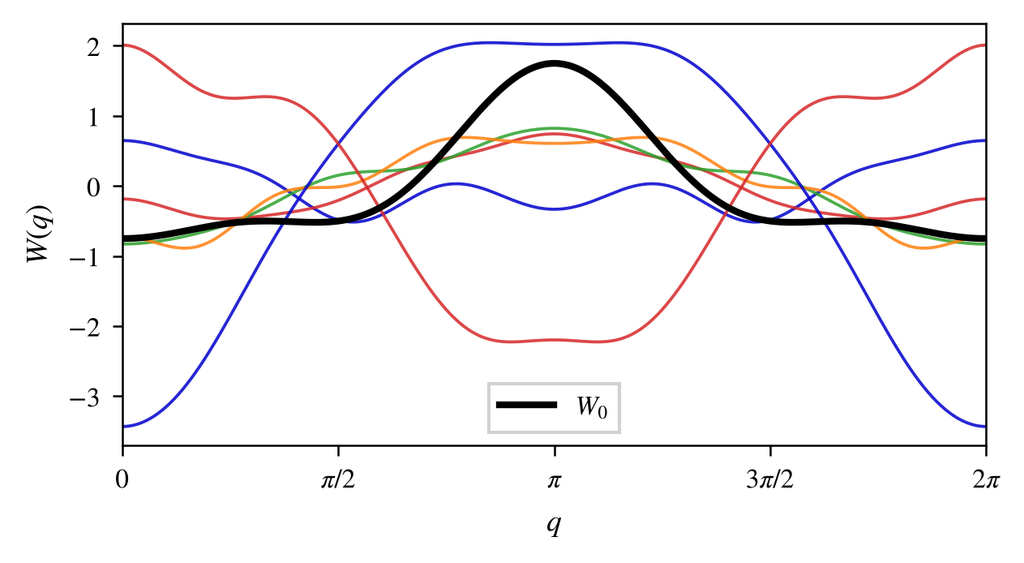

```python
def build_basis_cos(q, M):
    return np.stack([np.cos(m*q) for m in range(1, M+1)], axis=1)   # (Nq, M)

def make_scaling(M, tau=1.0, s=1.5):
    return np.array([tau/m**s for m in range(1, M+1)])          # prior s.d. of a_k: tau*k^(-s)

def W_from_xi(xi, Phi, scale):
    return Phi @ (scale*xi)

# truncation level K = M = 6 and s = alpha + 1 with prior regularity alpha = 1/2 (scale tau = 1)
M, tau, s = 6, 1.0, 1.5
Phi   = build_basis_cos(q, M)
scale = make_scaling(M, tau, s)
coef_true = cosine_coefficients(truth['W_true'], q, M)
rng = np.random.default_rng(1)
fig, ax = paper_figure(0.65, 2.2)
for _ in range(6):
    ax.plot(q_fine, W_from_xi(rng.standard_normal(M), build_basis_cos(q_fine, M), scale),
            lw=0.9, alpha=0.85)
ax.plot(q_fine, trig_interp(truth['W_true'], q_fine), 'k', lw=2, label='$W_0$')
set_q_axis(ax); ax.set_ylabel("$W(q)$"); ax.legend()
save_figure(fig, "prior_draws")
```

### 3.2.3 Likelihood and posterior sampling

One likelihood evaluation costs exactly one forward PDE solve. The posterior is sampled by the preconditioned Crank–Nicolson (pCN) algorithm in whitened coordinates, with a step size for each mode: of the order of the linearised posterior standard deviation on the modes which the data determine, and equal to one, that is, a fresh draw of the prior, on the others. The steps are set from the information of the data at $W=0$, not at the truth, and every chain starts from a draw of the prior.

Notation: the code variable `xi` holds the whitened coordinates, written $\theta$ in the paper, and `steps` holds the proposal standard deviations $\sqrt{2\delta_k}$, so that the proposal is $\theta'_k=\sqrt{1-2\delta_k}\,\theta_k+\sqrt{2\delta_k}\,\xi_k$ with $\xi\sim\mathcal N(0,I_K)$; the Jacobian of the prediction vector is $A$.

```python
# inference-resolution solver (coarser than the truth: N_H = 14, dt = 0.02) and observation basis
NH_inf, dt_inf = 14, 0.02
solver = KineticVFP(q, dq, k, NH_inf, truth['gamma'], truth['beta'], dt_inf, truth['V'])
c_init_inf = np.zeros((NH_inf, len(q))); c_init_inf[0] = truth['rho0']
Nt_inf = int(truth['T']/dt_inf)
B_obs = hermite_eval(NH_inf, p_obs, truth['beta'])   # e_n(p_i), for the f-likelihood

def predict_rho(xi):
    _, sol = solver.solve(W_from_xi(xi, Phi, scale), c_init_inf, Nt_inf, save_every=1)
    return sol[t_idx, 0, q_idx]                        # rho = c_0 only
def predict_f(xi):
    _, sol = solver.solve(W_from_xi(xi, Phi, scale), c_init_inf, Nt_inf, save_every=1)
    return np.einsum('in,in->i', sol[t_idx, :, q_idx], B_obs)   # full f = sum_n c_n e_n

def loglik_rho(xi): return -0.5*np.sum((Y_rho - predict_rho(xi))**2)/sig_rho**2
def loglik_f(xi):   return -0.5*np.sum((Y_f - predict_f(xi))**2)/sig_f**2

def information_diagonal(predict, xi, sigma, h=1e-3):
    """Diagonal of A^T A / sigma^2, with A the Jacobian of the prediction vector at xi (central differences): the
    information of the data on each whitened coordinate. Used only to set the pCN step sizes."""
    out = np.empty(len(xi))
    for m in range(len(xi)):
        e = np.zeros(len(xi)); e[m] = h
        d = (predict(xi + e) - predict(xi - e))/(2*h)
        out[m] = d @ d/sigma**2
    return out

def pcn_steps(info, c=1.5):
    """Proposal standard deviations sqrt(2 delta_k) = min(1, c/sqrt(1 + I_k)): of the order of the linearised posterior
    s.d. on the modes which the data determine, and one (delta_k = 1/2, a fresh prior draw) on the others."""
    return np.minimum(1.0, c/np.sqrt(1.0 + info))

def pcn(loglik, steps, n_iter, seed=1, log_every=None):
    """pCN with a step size delta_k for each mode (the operator-weighted proposal of Law, 2014) in whitened
    coordinates xi (theta in the paper): xi'_k = sqrt(1 - 2 delta_k) xi_k + sqrt(2 delta_k) g_k, g ~ N(0, I),
    accepted with probability min{1, exp(loglik(xi') - loglik(xi))}, where steps = sqrt(2 delta_k).
    The chain starts from a draw of the prior."""
    rng = np.random.default_rng(seed)
    steps = np.asarray(steps, dtype=float); damp = np.sqrt(1 - steps**2)
    xi = rng.standard_normal(len(steps)); ll = loglik(xi)
    samples = np.empty((n_iter, len(steps))); ll_chain = np.empty(n_iter); nacc = 0; t0 = time.time()
    for it in range(n_iter):
        xp = damp*xi + steps*rng.standard_normal(len(steps))
        lp = loglik(xp)
        if np.log(rng.random()) < lp - ll: xi, ll = xp, lp; nacc += 1
        samples[it], ll_chain[it] = xi, ll
        if log_every and (it+1) % log_every == 0:
            print(f"  iter {it+1:5d}/{n_iter}  acc={nacc/(it+1):5.1%}  ll={ll:9.1f}  t={time.time()-t0:5.0f}s")
    return samples, ll_chain, nacc/n_iter

def ess(x):
    """Effective sample size of a scalar chain (Geyer's initial positive sequence estimator)."""
    x = np.asarray(x, dtype=float) - np.mean(x); n = len(x)
    f = np.fft.rfft(x, 2*n); ac = np.fft.irfft(f*np.conj(f))[:n]; ac /= ac[0]
    s = 0.0
    for t in range(0, n - 1, 2):
        pair = ac[t] + ac[t+1]
        if pair <= 0: break
        s += pair
    return n/max(2*s - 1, 1.0)

steps_rho = pcn_steps(information_diagonal(predict_rho, np.zeros(M), sig_rho))   # at W = 0, not at the truth
steps_f   = pcn_steps(information_diagonal(predict_f,   np.zeros(M), sig_f))
print("pCN steps sqrt(2 delta_k), model (M1):", np.round(steps_rho, 3))
print("pCN steps sqrt(2 delta_k), model (M2):", np.round(steps_f, 3))
_t = time.time(); loglik_rho(np.zeros(M))
print(f"one likelihood evaluation: {time.time()-_t:.3f}s;  target plateau -N/2 = {-N_obs/2:.0f}")
```

```
pCN steps sqrt(2 delta_k), model (M1): [0.025 0.113 1.    1.    1.    1.   ]
pCN steps sqrt(2 delta_k), model (M2): [0.041 0.181 1.    1.    1.    1.   ]
one likelihood evaluation: 0.032s;  target plateau -N/2 = -1500
```

## 3.3 Posterior inference at fixed sample size

### 3.3.1 Posteriors from density and phase-space observations

Both models, with the same design, the same prior ($K=6$) and the same sampler: chains of 6000 iterations, of which the first fifth is discarded as burn-in.

```python
n_iter = 6000; burn = n_iter//5
samples_rho, ll_rho, acc_rho = pcn(loglik_rho, steps_rho, n_iter=n_iter, seed=1, log_every=1500)
samples_f,   ll_f,   acc_f   = pcn(loglik_f,   steps_f,   n_iter=n_iter, seed=1, log_every=1500)
post = {'rho': samples_rho[burn:], 'f': samples_f[burn:]}
acc = {'rho': acc_rho, 'f': acc_f}; traces = {'rho': ll_rho, 'f': ll_f}
coef_mean, coef_sd, W_post, rhoT_post, errW = {}, {}, {}, {}, {}
for model, name, col, mk in MODELS:
    ch = post[model]*scale
    coef_mean[model], coef_sd[model] = ch.mean(0), ch.std(0)
    W_post[model] = W_from_xi(post[model].mean(0), Phi, scale)                  # posterior mean on the grid
    _, sol_ = solver.solve(W_post[model], c_init_inf, Nt_inf, save_every=1); rhoT_post[model] = sol_[-1, 0]
    errW[model] = np.sqrt(torus_integral((W_post[model] - truth['W_true'])**2, dq))
    err_rhoT = np.sqrt(torus_integral((rhoT_post[model] - truth['sol_hi'][-1, 0])**2, dq))
    print(f"model {name}: acceptance {acc[model]:.1%};  effective sample sizes of a_1, ..., a_6: "
          f"{[int(ess(post[model][:, m])) for m in range(M)]} of {n_iter - burn}")
    print(f"           ||W_N - W_0||_L2 = {errW[model]:.4f};  ||rho_W_N(T) - rho_W_0(T)||_L2 = {err_rhoT:.1e} "
          f"(root-mean-square {err_rhoT/np.sqrt(2*np.pi):.1e});  mean log-likelihood after burn-in "
          f"{traces[model][burn:].mean():.0f}")
```

```
  iter  1500/6000  acc=32.0%  ll=  -1488.3  t=   54s
```

```
  iter  3000/6000  acc=31.7%  ll=  -1488.9  t=  107s
```

```
  iter  4500/6000  acc=32.4%  ll=  -1489.5  t=  159s
```

```
  iter  6000/6000  acc=32.0%  ll=  -1489.3  t=  208s
```

```
  iter  1500/6000  acc=34.1%  ll=  -1535.0  t=   51s
```

```
  iter  3000/6000  acc=33.6%  ll=  -1534.4  t=  106s
```

```
  iter  4500/6000  acc=34.5%  ll=  -1536.3  t=  158s
```

```
  iter  6000/6000  acc=34.2%  ll=  -1535.9  t=  211s
model (M1): acceptance 32.0%;  effective sample sizes of a_1, ..., a_6: [624, 341, 518, 829, 634, 725] of 4800
           ||W_N - W_0||_L2 = 0.2349;  ||rho_W_N(T) - rho_W_0(T)||_L2 = 7.0e-04 (root-mean-square 2.8e-04);  mean log-likelihood after burn-in -1490
model (M2): acceptance 34.2%;  effective sample sizes of a_1, ..., a_6: [512, 433, 507, 934, 694, 882] of 4800
           ||W_N - W_0||_L2 = 0.2609;  ||rho_W_N(T) - rho_W_0(T)||_L2 = 1.4e-03 (root-mean-square 5.7e-04);  mean log-likelihood after burn-in -1536
```

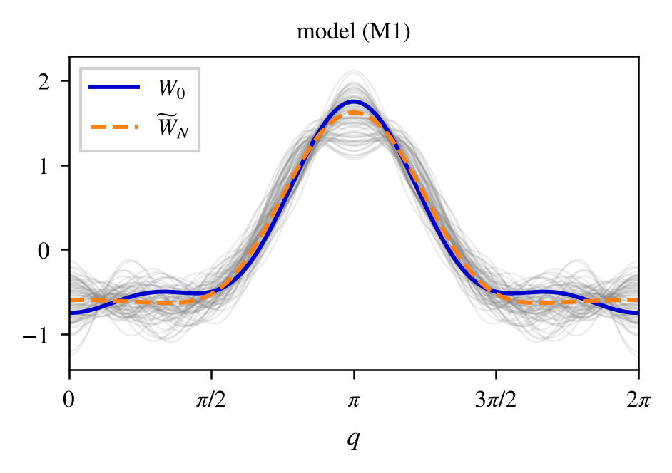

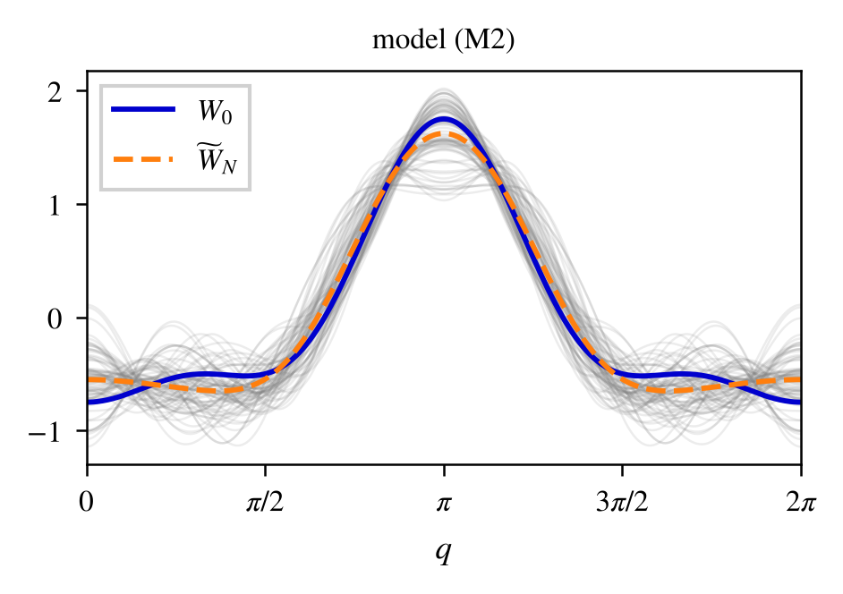

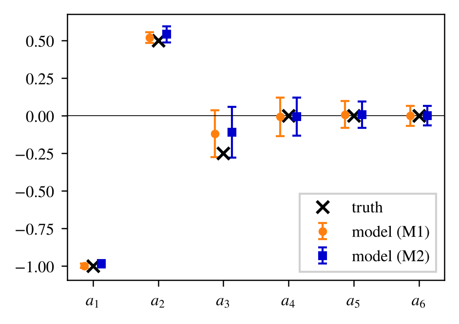

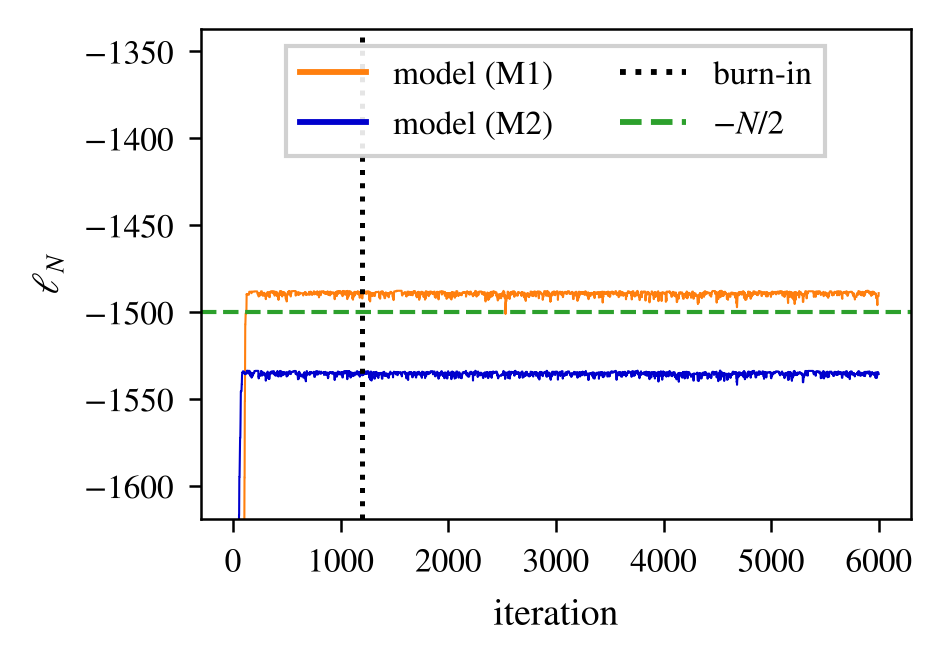

```
               a1     a2     a3     a4     a5     a6
truth     : -1.000 +0.500 -0.250 +0.000 +0.000 +0.000
(M1) mean: -0.997 +0.519 -0.119 -0.006 +0.008 -0.001
(M1) s.d.: +0.014 +0.036 +0.155 +0.128 +0.088 +0.066
(M2) mean: -0.984 +0.541 -0.110 -0.005 +0.008 -0.000
(M2) s.d.: +0.023 +0.054 +0.169 +0.126 +0.088 +0.065
prior s.d.: +1.000 +0.354 +0.192 +0.125 +0.089 +0.068
```

```python
rng_p = np.random.default_rng(7)
Phi_fine = build_basis_cos(q_fine, M)

# posterior draws, truth and posterior mean, for each model
for model, name, col, mk in MODELS:
    fig, ax = paper_figure(0.48, 2.1)
    plot_reconstruction(ax, post[model], Phi_fine, scale, truth['W_true'], rng_p)
    ax.set_title(f"model {name}", fontsize=8)
    save_figure(fig, f"W_posterior_{model}")

# cosine coefficients: posterior mean ± s.d. for both models against the truth
fig, ax = paper_figure(0.48, 2.1)
plot_coefficients_models(ax, coef_mean, coef_sd, coef_true)
save_figure(fig, "coeffs")

# log-likelihood traces
fig, ax = paper_figure(0.48, 2.1)
plot_traces(ax, traces, burn, N_obs, r"$\ell_N$")
save_figure(fig, "ll_trace")

print("            " + "  ".join(f"   a{m}" for m in range(1, M+1)))
print("truth     :", " ".join(f"{v:+.3f}" for v in coef_true))
for model, name, col, mk in MODELS:
    print(f"{name} mean:", " ".join(f"{v:+.3f}" for v in coef_mean[model]))
    print(f"{name} s.d.:", " ".join(f"{v:+.3f}" for v in coef_sd[model]))
print("prior s.d.:", " ".join(f"{v:+.3f}" for v in scale))
```

### 3.3.2 Identifiability: the Jacobian ladder and the linearised posterior

Linearising the forward map at the truth: the SVD of the Jacobian predicts, mode by mode, which Fourier frequencies of $W$ the data identify, for both models. This uses the truth and serves as a diagnostic of the experiment; it plays no part in the sampler.

```
model (M1): singular values [7.97e-01 1.13e-01 8.73e-03 5.86e-04 5.51e-05 3.38e-06]
           dominant mode of each singular direction [1, 2, 3, 4, 5, 6], weights [1. 1. 1. 1. 1. 1.]
           information I_k [5.24e+03 1.06e+02 6.28e-01 2.84e-03 2.51e-05 9.45e-08]
```

```
model (M2): singular values [1.74e-01 2.74e-02 2.05e-03 1.32e-04 1.28e-05 7.43e-07]
           dominant mode of each singular direction [1, 2, 3, 4, 5, 6], weights [1. 1. 1. 1. 1. 1.]
           information I_k [1.86e+03 4.60e+01 2.57e-01 1.06e-03 9.98e-06 3.38e-08]
ratio of the singular values to the largest, (M1) / (M2): [1.    0.906 0.932 0.975 0.946 0.997]
information ratio I^rho_k / I^f_k: [2.81 2.31 2.44 2.68 2.52 2.79]
```

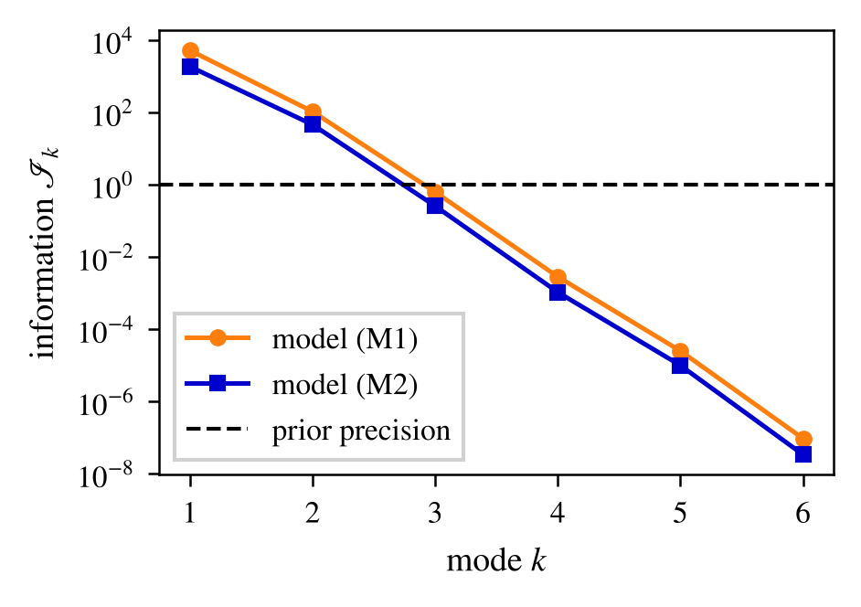

```python
# Linearise the forward map at W_true and read off the identifiability structure, for both models.
xi_true = coef_true/scale                         # the truth in whitened coordinates

def jacobian(predict, xi0, h=1e-3):
    base = predict(xi0); J = np.zeros((len(base), len(xi0)))
    for m in range(len(xi0)):
        e = np.zeros(len(xi0)); e[m] = h
        J[:, m] = (predict(xi0 + e) - predict(xi0 - e))/(2*h)
    return J

sig = {'rho': sig_rho, 'f': sig_f}
S, info = {}, {}
for model, name, col, mk in MODELS:
    U_, S[model], Vt = np.linalg.svd(jacobian(predict_rho if model == 'rho' else predict_f, xi_true), full_matrices=False)
    info[model] = (S[model]/sig[model])**2                           # per-mode information I_k = (sigma_k/sigma)^2
    dom = [int(np.argmax(np.abs(v))) + 1 for v in Vt]
    print(f"model {name}: singular values {np.array2string(S[model], formatter={'float_kind': lambda v: f'{v:.2e}'})}")
    print(f"           dominant mode of each singular direction {dom}, weights "
          f"{np.round([abs(v[d - 1]) for v, d in zip(Vt, dom)], 2)}")
    print(f"           information I_k {np.array2string(info[model], formatter={'float_kind': lambda v: f'{v:.2e}'})}")
print("ratio of the singular values to the largest, (M1) / (M2):", np.round((S['rho']/S['rho'][0])/(S['f']/S['f'][0]), 3))
print("information ratio I^rho_k / I^f_k:", np.round(info['rho']/info['f'], 2))

fig, ax = paper_figure(0.48, 2.1)
for model, name, col, mk in MODELS:
    ax.semilogy(np.arange(1, M+1), info[model], mk + '-', color=col, ms=3.5, label=f'model {name}')
ax.axhline(1.0, color='k', ls='--', lw=1, label='prior precision')
ax.set_xticks(np.arange(1, M+1)); ax.set_xlabel("mode $k$"); ax.set_ylabel(r"information $\mathscr{I}_k$")
ax.legend()
save_figure(fig, "info_ladder")
```

### 3.3.3 A weakly identified mode and the fully parametric limit

#### A ground truth with energy on a weakly identified mode (model (M2))

```
  iter  1500/6000  acc=21.7%  ll=  -1435.7  t=   50s
```

```
  iter  3000/6000  acc=20.5%  ll=  -1436.7  t=   99s
```

```
  iter  4500/6000  acc=20.3%  ll=  -1435.6  t=  147s
```

```
  iter  6000/6000  acc=19.7%  ll=  -1436.3  t=  195s
  acceptance 19.7%,  steps [0.04  0.187 1.    1.    1.    1.    1.    1.   ]
  effective sample sizes: [242, 360, 352, 377, 369, 262, 464, 401]

  true coeffs: [ 0.8  -0.6   0.4  -0.25  0.    0.    0.    0.  ]
  post coeffs: [ 0.79  -0.577  0.211 -0.004  0.005  0.005 -0.    -0.001]  +- [0.031 0.037 0.142 0.12  0.089 0.069 0.052 0.043]
```

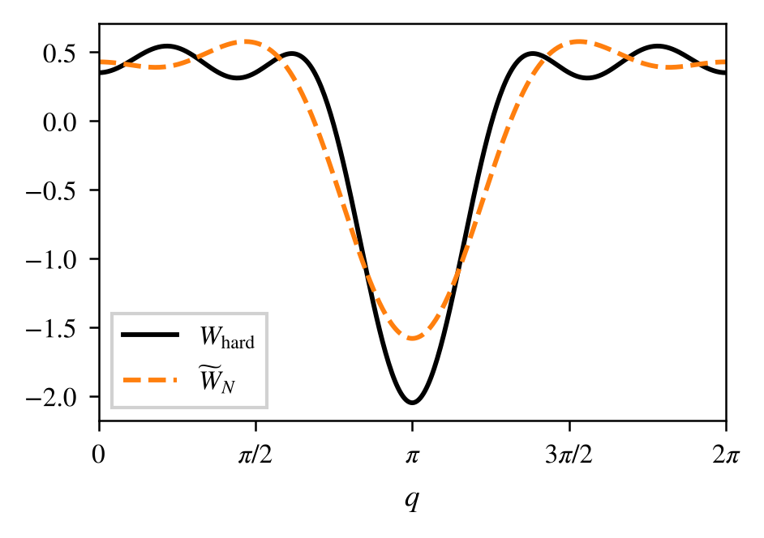

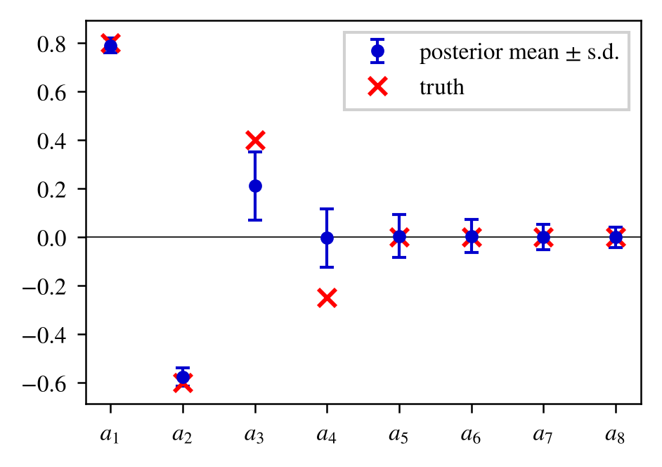

```python
# fine-solver "truth" for the harder potential, observed in model (M2) at its noise level
W_hard = 0.8*np.cos(q) - 0.6*np.cos(2*q) + 0.4*np.cos(3*q) - 0.25*np.cos(4*q)
truth_h = generate_truth(W_true=W_hard)

# observations: same type of design, new draws
rngh = np.random.default_rng(7)
Nh = 3000
ti = rngh.integers(1, len(truth_h['times']), Nh); qi = rngh.integers(0, len(q), Nh)
pi_h = rngh.uniform(-3.5, 3.5, Nh)
fH = np.einsum('in,in->i', truth_h['sol_hi'][ti, :, qi], hermite_eval(truth_h['NH_hi'], pi_h, truth['beta']))
YH = fH + sig_f*rngh.standard_normal(Nh)

# inference at the coarse resolution, with a wider prior, K = 8
Mh = 8
Phi_h = build_basis_cos(q, Mh); scale_h = make_scaling(Mh, 1.0, 1.5)
B_h = hermite_eval(NH_inf, pi_h, truth['beta'])
coef_true_h = cosine_coefficients(W_hard, q, Mh)

def predict_h(xi):
    _, s_ = solver.solve(W_from_xi(xi, Phi_h, scale_h), c_init_inf, Nt_inf, save_every=1)
    return np.einsum('in,in->i', s_[ti, :, qi], B_h)

def loglik_h(xi):
    return -0.5*np.sum((YH - predict_h(xi))**2)/sig_f**2

steps_h = pcn_steps(information_diagonal(predict_h, np.zeros(Mh), sig_f))
n_h = 6000
samp_h, _, acc_h = pcn(loglik_h, steps_h, n_iter=n_h, seed=3, log_every=1500)
print(f"  acceptance {acc_h:.1%},  steps {np.round(steps_h, 3)}")
post_h = samp_h[n_h//5:]*scale_h
print("  effective sample sizes:", [int(ess(post_h[:, m])) for m in range(Mh)])
cmh, csh = post_h.mean(0), post_h.std(0)
print(f"\n  true coeffs: {np.round(coef_true_h,3)}")
print(f"  post coeffs: {np.round(cmh,3)}  +- {np.round(csh,3)}")

fig, ax = paper_figure(0.48, 2.1)
ax.plot(q_fine, trig_interp(W_hard, q_fine), 'k', lw=1.4, label=r'$W_{\mathrm{hard}}$')
ax.plot(q_fine, build_basis_cos(q_fine, Mh) @ cmh, '--', color='C3', lw=1.4, label=r'$\widetilde{W}_N$')
set_q_axis(ax); ax.legend(loc='lower left')
save_figure(fig, "W_hard_recon")

fig, ax = paper_figure(0.48, 2.1)
plot_coefficients(ax, cmh, csh, coef_true_h)
save_figure(fig, "W_hard_coeffs")
```

#### The fully parametric limit

```
fully parametric truncation for Nq=48:  K = 23
```

```
  model (M1)  K= 3   acc=31.6%   ||W_N - W_0||_L2 = 0.2065   min ESS = 265
```

```
  model (M1)  K= 6   acc=32.2%   ||W_N - W_0||_L2 = 0.2308   min ESS = 275
```

```
  model (M1)  K=12   acc=31.6%   ||W_N - W_0||_L2 = 0.2206   min ESS = 201
```

```
  model (M1)  K=23   acc=31.7%   ||W_N - W_0||_L2 = 0.2167   min ESS = 114
```

```
  model (M2)  K= 3   acc=32.2%   ||W_N - W_0||_L2 = 0.2467   min ESS = 219
```

```
  model (M2)  K= 6   acc=33.9%   ||W_N - W_0||_L2 = 0.2587   min ESS = 296
```

```
  model (M2)  K=12   acc=32.7%   ||W_N - W_0||_L2 = 0.2528   min ESS = 243
```

```
  model (M2)  K=23   acc=34.5%   ||W_N - W_0||_L2 = 0.2726   min ESS = 245

sweep wall-clock: 1003s
```

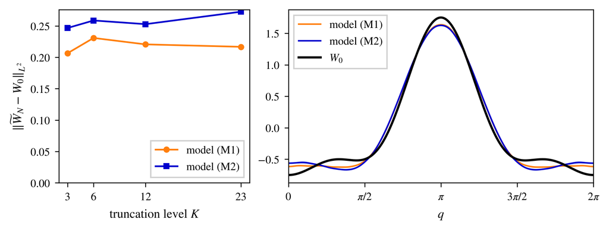

```python
# sweep the truncation level K (= Mtry) from a few modes up to the fully parametric limit, for both models
def run_pcn_M(model, Mtry, n_iter=4000, seed=1, s_prior=1.5, tau_prior=1.0):
    """Self-contained pCN at truncation level K = Mtry (leaves the globals of the K = 6 runs untouched)."""
    Phi_M   = build_basis_cos(q, Mtry)
    scale_M = make_scaling(Mtry, tau_prior, s_prior)
    if model == 'rho':
        Y_, sig_, obs = Y_rho, sig_rho, (lambda sol: sol[t_idx, 0, q_idx])
    else:
        Y_, sig_, obs = Y_f, sig_f, (lambda sol: np.einsum('in,in->i', sol[t_idx, :, q_idx], B_obs))
    def predict(xi):
        return obs(solver.solve(Phi_M @ (scale_M*xi), c_init_inf, Nt_inf, save_every=1)[1])
    def loglik(xi):
        return -0.5*np.sum((Y_ - predict(xi))**2)/sig_**2
    steps_M = pcn_steps(information_diagonal(predict, np.zeros(Mtry), sig_))
    samples, _, acc_M = pcn(loglik, steps_M, n_iter, seed=seed)
    return dict(samples=samples, scale=scale_M, Phi=Phi_M, acc=acc_M, n_iter=n_iter)

M_full = len(q)//2 - 1            # every cosine mode the Nq-point grid resolves, except the Nyquist mode
M_grid = [3, 6, 12, M_full]
print(f"fully parametric truncation for Nq={len(q)}:  K = {M_full}\n")

sweeps = {'rho': {}, 'f': {}}
t0 = time.time()
for model, name, col, mk in MODELS:
    for Mtry in M_grid:
        res  = run_pcn_M(model, Mtry)
        post_M = res['samples'][res['n_iter']//5:]          # discard the first fifth as burn-in
        res['post'] = post_M
        res['errW'] = np.sqrt(torus_integral((res['Phi'] @ (res['scale']*post_M.mean(0)) - truth['W_true'])**2, dq))
        sweeps[model][Mtry] = res
        print(f"  model {name}  K={Mtry:2d}   acc={res['acc']:5.1%}   ||W_N - W_0||_L2 = {res['errW']:.4f}   "
              f"min ESS = {min(int(ess(post_M[:, m])) for m in range(Mtry))}")
print(f"\nsweep wall-clock: {time.time()-t0:.0f}s")

plot_sweep_models(sweeps, truth['W_true'], "Msweep")
```

#### Linearised posterior and posterior marginals (Section 3.3.2)

The linearisation at the truth at the fully parametric truncation $K=23$, for both models, computed here because the empirical shrinkage uses the pCN chains at $K=23$ of the sweep above.

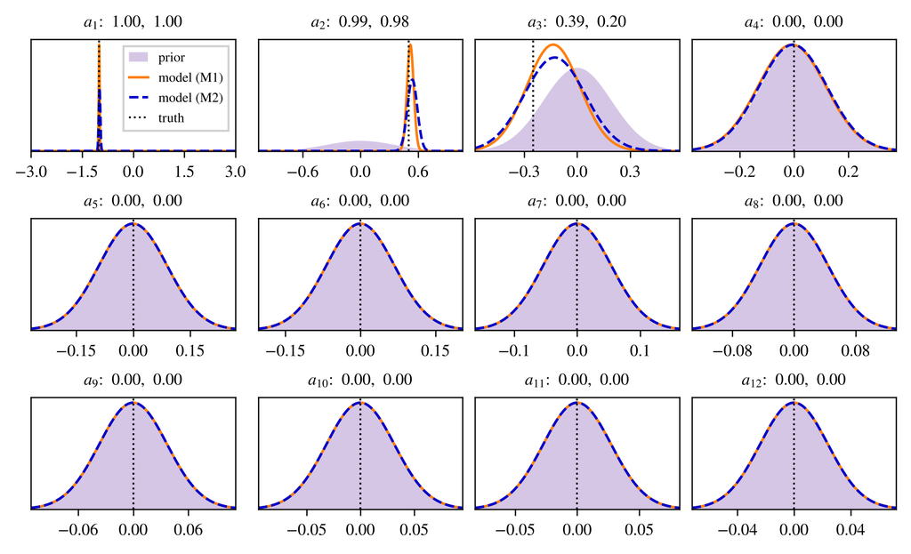

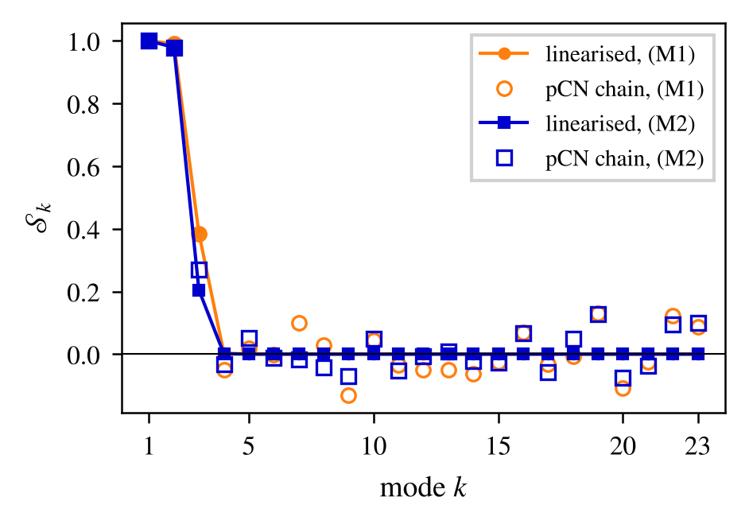

```
k                         :         1         2         3         4         5         6         7         8
S_k linearised, (M1)     :  1.00e+00  9.90e-01  3.86e-01  3.12e-03  2.84e-05  1.23e-07  8.51e-10  9.50e-12
S_k pCN chain K=23, (M1) :  1.00e+00  9.91e-01  3.85e-01 -4.92e-02  1.79e-02 -6.89e-04  1.01e-01  2.92e-02
linearised s.d. a_k, (M1):  1.40e-02  3.46e-02  1.51e-01  1.25e-01  8.94e-02  6.80e-02  5.40e-02  4.42e-02
linearised mean a_k, (M1): -9.98e-01  5.19e-01 -1.35e-01 -7.72e-03 -7.29e-04 -2.63e-05 -2.24e-06 -3.25e-07
S_k linearised, (M2)     :  9.99e-01  9.79e-01  2.05e-01  1.11e-03  1.06e-05  3.96e-08  4.15e-10  4.85e-12
S_k pCN chain K=23, (M2) :  9.99e-01  9.77e-01  2.70e-01 -3.28e-02  5.11e-02 -1.06e-02 -1.63e-02 -4.19e-02
linearised s.d. a_k, (M2):  2.36e-02  5.16e-02  1.72e-01  1.25e-01  8.94e-02  6.80e-02  5.40e-02  4.42e-02
linearised mean a_k, (M2): -9.87e-01  5.39e-01 -1.27e-01 -3.93e-03 -3.39e-04 -2.55e-06 -7.72e-07 -5.79e-08
```

```python
# linearised posterior per mode at the fully parametric truncation, for both models
Phi_full   = build_basis_cos(q, M_full)
scale_full = make_scaling(M_full, 1.0, 1.5)
coef_true_full = cosine_coefficients(truth['W_true'], q, M_full)
xi_true_full = coef_true_full / scale_full

def predict_rho_full(xi):
    _, sol = solver.solve(Phi_full @ (scale_full*xi), c_init_inf, Nt_inf, save_every=1)
    return sol[t_idx, 0, q_idx]
def predict_f_full(xi):
    _, sol = solver.solve(Phi_full @ (scale_full*xi), c_init_inf, Nt_inf, save_every=1)
    return np.einsum('in,in->i', sol[t_idx, :, q_idx], B_obs)

def linearised_posterior(predict, Y, sig_):
    """Shrinkage S_k, posterior s.d. and posterior mean in whitened coordinates of the linearised posterior at the
    truth: the forward map linearised at the truth (Gauss-Newton expansion of the log-likelihood) combined with the
    N(0, I) prior on the whitened coordinates."""
    h = 1e-3; F0 = predict(xi_true_full); J = np.zeros((len(F0), M_full))
    for m in range(M_full):
        e = np.zeros(M_full); e[m] = h
        J[:, m] = (predict(xi_true_full + e) - predict(xi_true_full - e)) / (2*h)
    Sig = np.linalg.inv(np.eye(M_full) + J.T @ J / sig_**2)
    mean = xi_true_full + Sig @ (J.T @ (Y - F0)/sig_**2 - xi_true_full)
    return 1 - np.diag(Sig), np.sqrt(np.clip(np.diag(Sig), 0, None)), mean

lin_post = {}
for model, pred_full, Y_ in (('rho', predict_rho_full, Y_rho), ('f', predict_f_full, Y_f)):
    shrink_, sd_w, mean_w = linearised_posterior(pred_full, Y_, sig_rho if model == 'rho' else sig_f)
    lin_post[model] = dict(shrink=shrink_, sd=scale_full*sd_w, mean=scale_full*mean_w)
prior_sd = scale_full

# prior against linearised posterior marginals, mode by mode (first 12 modes), for both models
plot_marginals(prior_sd, lin_post, coef_true_full, name="marginals")

# linearised shrinkage over all modes, with the empirical shrinkage of the pCN chains at K = 23
modes = np.arange(1, M_full+1)
emp_shrink = {model: 1 - ((sweeps[model][M_full]['post']*scale_full).std(0)/prior_sd)**2 for model in sweeps}
fig, ax = paper_figure(0.48, 2.1)
for model, name, col, mk in MODELS:
    ax.plot(modes, lin_post[model]['shrink'], mk + '-', color=col, ms=2.8, lw=1, label=f'linearised, {name}')
    ax.plot(modes, emp_shrink[model], mk, color=col, ms=4.2, mfc='none', mew=0.8, label=f'pCN chain, {name}')
ax.axhline(0, color='k', lw=0.5)
ax.set_xticks([1, 5, 10, 15, 20, 23])
ax.set_xlabel("mode $k$"); ax.set_ylabel(r"$\mathscr{S}_k$")
ax.legend(loc='upper right', fontsize=7)
save_figure(fig, "shrinkage")

fmt = {'float_kind': lambda v: f'{v:9.2e}'}
print("k                         :", " ".join(f"{m:9d}" for m in range(1, 9)))
for model, name, col, mk in MODELS:
    print(f"S_k linearised, {name}     :", np.array2string(lin_post[model]['shrink'][:8], formatter=fmt, max_line_width=200)[1:-1])
    print(f"S_k pCN chain K=23, {name} :", np.array2string(emp_shrink[model][:8], formatter=fmt, max_line_width=200)[1:-1])
    print(f"linearised s.d. a_k, {name}:", np.array2string(lin_post[model]['sd'][:8], formatter=fmt, max_line_width=200)[1:-1])
    print(f"linearised mean a_k, {name}:", np.array2string(lin_post[model]['mean'][:8], formatter=fmt, max_line_width=200)[1:-1])
```

## 3.4 Posterior contraction as the sample size grows

Both measurement models, with the prior of Section 3.2.2 ($K=6$, $\alpha=1/2$) kept fixed and the designs and noise levels of Section 3.2.1. For each of $R=8$ independent sequences of observations, the posterior given the first $N$ observations is sampled, for $N=500\cdot2^j$, $j=0,\dots,7$, by $C=2$ independent pCN chains of $3000$ iterations. Recorded: the posterior root-mean-square distance $r_N(\mathcal G)$ to the truth of the forward quantity in the design norm, and those of $\pi_2W$ (modes 1–2) and of $W$ in $L^2$, averaged over the sequences (root mean square), with the range over the sequences; their linearised prediction at the truth, averaged over the noise; the fitted exponents, with their jackknife standard errors over the sequences; and the diagnostics of the chains: acceptance rates, effective sample sizes, split-$\hat R$ and Monte Carlo standard errors.

The long run of this section advances all chains of a given $N$ together, with the batched version of the solver defined in the next cell.

```python
# Batched solver for the long run of Section 3.4: the same Strang splitting with exact substeps as
# KineticVFP, advancing B interactions at once (c of shape (B, N_H, N_q)) on real FFTs, which amortises the
# per-step overhead over many chains; it agrees with KineticVFP to rounding error (check below).
def force_kick_batch(c, A, tau, beta):
    """force_kick for a batch, c (B, NH, Nq), A (B, Nq): the j-th term of the finite Taylor sum lives on the levels n >= j."""
    NH = c.shape[1]; sb = np.sqrt(beta*np.arange(NH))
    out = c.copy(); term = c
    for j in range(1, NH):
        term = (tau/j)*sb[j:, None]*A[:, None, :]*term[:, :-1]
        out[:, j:] += term
    return out

class KineticVFPBatch:
    def __init__(self, q, dq, k, NH, gamma, beta, dt, V):
        self.q, self.dq, self.NH, self.gamma, self.beta, self.dt = q, dq, NH, gamma, beta, dt
        self.Nq = len(q); self.kr = np.abs(k[:self.Nq//2 + 1])             # wavenumbers 0, ..., Nq/2 of the real FFT
        self.dV = np.real(np.fft.ifft(1j*k*np.fft.fft(V)))
        _, self.Er = build_linear_exponentials(self.kr, NH, gamma, beta, dt)  # exp(dt L_k), (Nq/2+1, NH, NH)
    def force_field(self, rho, W_hat):
        return -self.dV - np.fft.irfft(1j*self.kr*self.dq*W_hat*np.fft.rfft(rho, axis=-1), n=self.Nq, axis=-1)
    def linear_step(self, c):
        chat = np.matmul(self.Er, np.fft.rfft(c, axis=-1).transpose(2, 1, 0)).transpose(2, 1, 0)
        return np.fft.irfft(chat, n=self.Nq, axis=-1)
    def solve(self, W, c_init, Nt, save_every=1):
        """Solutions for the interactions W (B, Nq) from the common initial coefficients c_init (NH, Nq): (Ns, B, NH, Nq)."""
        W = np.atleast_2d(W); W_hat = np.fft.rfft(W, axis=-1); dt = self.dt
        c = np.broadcast_to(c_init, (W.shape[0],) + c_init.shape).copy()
        saved, times = [c.copy()], [0.0]
        for nstep in range(Nt):
            c = force_kick_batch(c, self.force_field(c[:, 0], W_hat), dt/2, self.beta)
            c = self.linear_step(c)
            c = force_kick_batch(c, self.force_field(c[:, 0], W_hat), dt/2, self.beta)
            if (nstep+1) % save_every == 0:
                saved.append(c.copy()); times.append((nstep+1)*dt)
        return np.array(times), np.array(saved)

def split_rhat(x):
    """Split-R-hat of the chains x of shape (C, n) [Gelman et al., Bayesian Data Analysis, 3rd ed., Sec. 11.4]."""
    n2 = x.shape[1]//2
    h = np.concatenate([x[:, :n2], x[:, n2:2*n2]])
    W_, B_ = h.var(axis=1, ddof=1).mean(), n2*h.mean(axis=1).var(ddof=1)
    return np.sqrt(((n2 - 1)/n2*W_ + B_/n2)/W_)

solver_b = KineticVFPBatch(q, dq, k, NH_inf, truth['gamma'], truth['beta'], dt_inf, truth['V'])
xis_chk = np.random.default_rng(5).standard_normal((32, M))
Ws_chk = xis_chk @ (scale[:, None]*Phi.T)
t_b = time.time(); _, sol_b = solver_b.solve(Ws_chk, c_init_inf, Nt_inf); t_b = time.time() - t_b
t_s = time.time(); sol_s = np.array([solver.solve(W_, c_init_inf, Nt_inf)[1] for W_ in Ws_chk]); t_s = time.time() - t_s
print(f"32 interactions: max|batched - sequential| = {np.abs(sol_b.transpose(1, 0, 2, 3) - sol_s).max():.1e};  "
      f"{t_b:.2f}s batched against {t_s:.2f}s sequential")
```

```
32 interactions: max|batched - sequential| = 1.4e-15;  0.13s batched against 1.01s sequential
```

```python
# R independent sequences of observations for each model, drawn from the designs of Section 3.2.1 at its
# noise levels; for each sequence, the posterior given its first N observations is sampled, for
# N = 500*2^j, j = 0, ..., 7, by C independent pCN chains. Along a sequence, each chain starts, for each N, from its
# own last state for the previous N (at N = 500, the C chains start from independent draws of the prior), as the
# posterior concentrates by a factor of order 1/sqrt(2) from one N to the next. All R x 2 x C chains of a given N
# advance together, with one batched forward solve per iteration (KineticVFPBatch). Averaging over the R sequences
# estimates the expectation over the data, which the linearised prediction of the next cell computes; the C chains
# of each posterior give the between-chain diagnostics.
N_grid = [500*2**j for j in range(8)]
R, C = 8, 2
n_iter_rate = 3000; burn_rate = n_iter_rate//5
models = ('rho', 'f')

# design norms over the whole design: the 100 positive snapshot times x 48 grid points and, for f,
# the uniform momentum design on [-3.5, 3.5] (Gauss-Legendre quadrature of the products e_n e_m)
p_gl, w_gl = np.polynomial.legendre.leggauss(40); p_gl = 3.5*p_gl; w_gl = w_gl/2
B_gl = hermite_eval(NH_inf, p_gl, truth['beta'])
G_p = B_gl.T @ (w_gl[:, None]*B_gl)

def forward_fields(xi):
    _, sol = solver.solve(W_from_xi(xi, Phi, scale), c_init_inf, Nt_inf, save_every=1)
    return sol[1:]                                                  # (100, NH, Nq)
fields_0 = forward_fields(xi_true)
def dist2_rho(sol): return np.mean((sol[:, 0, :] - fields_0[:, 0, :])**2)
def dist2_f(sol):
    d = (sol - fields_0).transpose(1, 0, 2).reshape(NH_inf, -1)     # (NH, 100 x Nq)
    return np.mean(np.sum(d*(G_p @ d), axis=0))
dist2 = {'rho': dist2_rho, 'f': dist2_f}

def observation_sequence(seed, N_max):
    rng_seq = np.random.default_rng(seed)
    t_s = rng_seq.integers(1, len(truth['times']), N_max)          # positive snapshot times
    q_s = rng_seq.integers(0, len(q), N_max)
    p_s = rng_seq.uniform(-3.5, 3.5, N_max)
    Yf = np.einsum('in,in->i', truth['sol_hi'][t_s, :, q_s],
                   hermite_eval(truth['NH_hi'], p_s, truth['beta'])) + sig_f*rng_seq.standard_normal(N_max)
    Yr = truth['sol_hi'][t_s, 0, q_s] + sig_rho*rng_seq.standard_normal(N_max)
    return dict(t=t_s, q=q_s, B=hermite_eval(NH_inf, p_s, truth['beta']), Yf=Yf, Yr=Yr)

seqs = [observation_sequence(2026 + r, N_grid[-1]) for r in range(R)]
chains = [(model, r, c) for model in models for r in range(R) for c in range(C)]
state = {ch: np.random.default_rng(100*(ch[2] + 1) + ch[1]).standard_normal(M) for ch in chains}  # prior draws

def likelihood_setup(model, r, N):
    """Data, noise level and predicted observations (from a solution array) of the first N observations."""
    seq = seqs[r]; t_, q_ = seq['t'][:N], seq['q'][:N]
    if model == 'rho':
        return seq['Yr'][:N], sig_rho, lambda sol: sol[t_, 0, q_]
    B_ = seq['B'][:N]
    return seq['Yf'][:N], sig_f, lambda sol: np.einsum('in,in->i', sol[t_, :, q_], B_)

# runs[model][r][N]: posterior means of the squared distances, and the diagnostics of the C chains
runs = {model: [dict() for _ in range(R)] for model in models}
t0 = time.time()
for N in N_grid:
    setups = {(model, r): likelihood_setup(model, r, N) for model in models for r in range(R)}
    steps_, rngs = [], []
    for model, r, c in chains:
        Y_, sig_, pred = setups[(model, r)]
        if c == 0:                                       # step sizes from the information at W = 0
            st = pcn_steps(information_diagonal(lambda xi: pred(solver.solve(W_from_xi(xi, Phi, scale), c_init_inf,
                                                                              Nt_inf, save_every=1)[1]),
                                                np.zeros(M), sig_))
        steps_.append(st); rngs.append(np.random.default_rng([1000*r + N, c, models.index(model)]))
    steps_ = np.array(steps_); damp = np.sqrt(1 - steps_**2)
    nb_ = len(chains)
    def loglik_batch(xis):
        """Log-likelihoods of the states xis (B, M) of all chains, and the solutions, from one batched solve."""
        sols = solver_b.solve(xis @ (scale[:, None]*Phi.T), c_init_inf, Nt_inf)[1]     # (Ns, B, NH, Nq)
        ll_ = np.empty(nb_)
        for b, (model, r, c) in enumerate(chains):
            Y_, sig_, pred = setups[(model, r)]
            ll_[b] = -0.5*np.sum((Y_ - pred(sols[:, b]))**2)/sig_**2
        return ll_, sols
    xi = np.array([state[ch] for ch in chains])
    ll, sols = loglik_batch(xi)
    d2 = np.array([dist2[ch[0]](sols[1:, b]) for b, ch in enumerate(chains)])
    rec_xi = np.empty((nb_, n_iter_rate - burn_rate, M)); rec_d2 = np.empty((nb_, n_iter_rate - burn_rate))
    n_acc = np.zeros(nb_)
    for it in range(n_iter_rate):
        xp = damp*xi + steps_*np.array([g.standard_normal(M) for g in rngs])
        lp, sols = loglik_batch(xp)
        for b, g in enumerate(rngs):
            if np.log(g.random()) < lp[b] - ll[b]:
                xi[b], ll[b], d2[b] = xp[b], lp[b], dist2[chains[b][0]](sols[1:, b]); n_acc[b] += 1
        if it >= burn_rate:
            rec_xi[:, it - burn_rate], rec_d2[:, it - burn_rate] = xi, d2
    for b, ch in enumerate(chains):
        state[ch] = xi[b].copy()
    # summaries over the C chains of each posterior
    for model in models:
        for r in range(R):
            idx = [b for b, ch in enumerate(chains) if ch[0] == model and ch[1] == r]
            a_err = rec_xi[idx]*scale - coef_true                                     # (C, n, M)
            fun = {'fwd2': rec_d2[idx], 'pi2_2': np.pi*np.sum(a_err[..., :2]**2, -1),
                   'W2': np.pi*np.sum(a_err**2, -1)}
            ess_of = lambda x: sum(ess(xc) for xc in x)                                 # summed over the chains
            out = {key: val.mean() for key, val in fun.items()}
            out['mcse'] = {key: val.std()/np.sqrt(ess_of(val)) for key, val in fun.items()}
            out['acc'] = n_acc[idx]/n_iter_rate
            out['ess'] = min(ess_of(rec_xi[idx][..., m]) for m in range(2))           # of a_1 and a_2
            out['rhat'] = max([split_rhat(rec_xi[idx][..., m]) for m in range(2)]
                              + [split_rhat(fun[key]) for key in fun])
            runs[model][r][N] = out
    print(f"N = {N:5d} done  [{time.time() - t0:.0f}s]")

# posterior root-mean-square distances, averaged over the R sequences of data, and their Monte Carlo errors
def average(model, key, rs=None):
    rs = range(R) if rs is None else rs
    return np.array([np.sqrt(np.mean([runs[model][r][N][key] for r in rs])) for N in N_grid])
def spread(model, key):
    vals = np.array([[np.sqrt(runs[model][r][N][key]) for r in range(R)] for N in N_grid])
    return vals.min(1), vals.max(1)
def rel_mcse(model, key):
    """Monte Carlo standard error of r_N relative to r_N (delta method), at each N."""
    return np.array([0.5*np.sqrt(sum(runs[model][r][N]['mcse'][key]**2 for r in range(R)))
                     / sum(runs[model][r][N][key] for r in range(R)) for N in N_grid])
rates = {model: {key: average(model, key) for key in ('fwd2', 'pi2_2', 'W2')} for model in models}
n_kept = C*(n_iter_rate - burn_rate)
for model, name, sig in (('rho', '(M1)', sig_rho), ('f', '(M2)', sig_f)):
    acc = np.concatenate([runs[model][r][N]['acc'] for r in range(R) for N in N_grid])
    print(f"{name}: r_N(G)/sigma = " + " ".join(f"{v:.2e}" for v in rates[model]['fwd2']/sig))
    print(f"      r_N(pi_2 W)  = " + " ".join(f"{v:.4f}" for v in rates[model]['pi2_2']))
    print(f"      r_N(W)       = " + " ".join(f"{v:.3f}" for v in rates[model]['W2']))
    print(f"      acceptance {acc.min():.0%}-{acc.max():.0%},  min ESS of a_1, a_2: "
          f"{min(int(runs[model][r][N]['ess']) for r in range(R) for N in N_grid)} of {n_kept},  max split-R-hat: "
          f"{max(runs[model][r][N]['rhat'] for r in range(R) for N in N_grid):.3f}")
    print("      relative Monte Carlo error of r_N(G): " + " ".join(f"{v:.1%}" for v in rel_mcse(model, 'fwd2'))
          + ";  of r_N(pi_2 W): max " + f"{rel_mcse(model, 'pi2_2').max():.1%}")
```

```
N =   500 done  [429s]
```

```
N =  1000 done  [857s]
```

```
N =  2000 done  [1274s]
```

```
N =  4000 done  [1704s]
```

```
N =  8000 done  [2140s]
```

```
N = 16000 done  [2584s]
```

```
N = 32000 done  [3064s]
```

```
N = 64000 done  [3620s]
(M1): r_N(G)/sigma = 8.67e-02 6.23e-02 4.48e-02 3.29e-02 2.53e-02 1.78e-02 1.32e-02 9.04e-03
      r_N(pi_2 W)  = 0.2001 0.1577 0.0944 0.0774 0.0559 0.0401 0.0257 0.0162
      r_N(W)       = 0.669 0.637 0.586 0.509 0.459 0.382 0.368 0.339
      acceptance 20%-43%,  min ESS of a_1, a_2: 225 of 4800,  max split-R-hat: 1.022
      relative Monte Carlo error of r_N(G): 0.6% 0.6% 0.5% 0.6% 0.6% 0.6% 0.6% 0.6%;  of r_N(pi_2 W): max 1.0%
(M2): r_N(G)/sigma = 8.34e-02 6.36e-02 4.37e-02 3.71e-02 2.48e-02 1.74e-02 1.31e-02 9.49e-03
      r_N(pi_2 W)  = 0.3109 0.2583 0.1768 0.1527 0.0957 0.0676 0.0509 0.0328
      r_N(W)       = 0.702 0.656 0.620 0.577 0.501 0.472 0.391 0.362
      acceptance 21%-42%,  min ESS of a_1, a_2: 202 of 4800,  max split-R-hat: 1.025
      relative Monte Carlo error of r_N(G): 0.6% 0.6% 0.6% 0.6% 0.6% 0.6% 0.6% 0.6%;  of r_N(pi_2 W): max 1.0%
```

```
(M1): fitted exponents over N = 500-64000:  forward 0.457 +- 0.022 (Monte Carlo 0.001; linearised 0.461),  pi_2 W 0.508 +- 0.018 (Monte Carlo 0.002; linearised 0.495)
      chain / linearised, forward: 0.95 0.94 0.92 0.92 0.97 0.95 0.98 0.94
      chain / linearised, pi_2 W : 0.87 0.96 0.81 0.93 0.95 0.96 0.87 0.78
      sum of shrinkages d_N      : 2.03 2.14 2.27 2.44 2.61 2.77 2.89 2.98
      r_N(W): chain 0.669 -> 0.339,  linearised 0.653 -> 0.327
(M2): fitted exponents over N = 500-64000:  forward 0.451 +- 0.022 (Monte Carlo 0.001; linearised 0.458),  pi_2 W 0.468 +- 0.034 (Monte Carlo 0.002; linearised 0.494)
      chain / linearised, forward: 0.94 0.99 0.94 1.10 1.00 0.96 1.00 1.00
      chain / linearised, pi_2 W : 0.89 1.03 0.99 1.20 1.06 1.06 1.12 1.02
      sum of shrinkages d_N      : 1.91 2.01 2.10 2.22 2.38 2.55 2.72 2.85
      r_N(W): chain 0.702 -> 0.362,  linearised 0.716 -> 0.362
theorem's exponent (alpha+1+kappa)/(2(alpha+1)+2 kappa+1) at alpha = 1/2: kappa=1: 0.417, kappa=2: 0.438, kappa=5: 0.464, kappa=10: 0.479, kappa=50: 0.495
```

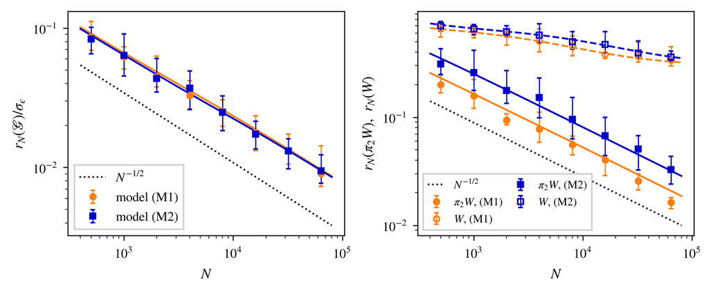

```python
# Linearised prediction, averaged over the noise. With A the Jacobian of the forward fields at the
# truth and G its Gram matrix per observation in the design norm, the linearised posterior given N
# observations has covariance Sigma_N = (I + N G/sigma^2)^{-1} in whitened coordinates, and
#     E (xi - xi_0)(xi - xi_0)^T = Sigma_N + Sigma_N (N G/sigma^2) Sigma_N + Sigma_N xi_0 xi_0^T Sigma_N,
# spread + noise in the posterior mean + bias from the prior, under posterior and noise.
h = 1e-3
dfields = np.array([(forward_fields(xi_true + h*e) - forward_fields(xi_true - h*e))/(2*h)
                    for e in np.eye(M)])                             # (M, 100, NH, Nq)
n_design = dfields.shape[1]*dfields.shape[3]
G_rho = np.einsum('atq,btq->ab', dfields[:, :, 0, :], dfields[:, :, 0, :])/n_design
G_f = np.einsum('atnq,nm,btmq->ab', dfields, G_p, dfields)/n_design

def linearised_rates(G, sig, Ns):
    out = {'fwd': [], 'pi2': [], 'W': [], 'dim': []}
    for N in Ns:
        A = N*G/sig**2; S = np.linalg.inv(np.eye(M) + A)
        C_ = S + S @ A @ S + S @ np.outer(xi_true, xi_true) @ S
        Ca = scale[:, None]*C_*scale[None, :]                         # in the coefficients a_k
        out['fwd'].append(np.sqrt(np.trace(G @ C_)))
        out['pi2'].append(np.sqrt(np.pi*np.trace(Ca[:2, :2]))); out['W'].append(np.sqrt(np.pi*np.trace(Ca)))
        out['dim'].append(np.trace(np.eye(M) - S))                    # sum of the shrinkages S_k
    return {key: np.array(val) for key, val in out.items()}

N_line = np.logspace(np.log10(400), np.log10(8e4), 60)
lin = {'rho': linearised_rates(G_rho, sig_rho, N_line), 'f': linearised_rates(G_f, sig_f, N_line)}
lin_grid = {'rho': linearised_rates(G_rho, sig_rho, N_grid), 'f': linearised_rates(G_f, sig_f, N_grid)}

# fitted exponents, with the jackknife standard error over the R sequences (which includes the Monte Carlo error) and
# the Monte Carlo part alone (parametric bootstrap of the posterior means within their Monte Carlo standard errors)
Ns = np.array(N_grid)
def slope(y, Ns=Ns): return -np.polyfit(np.log(Ns), np.log(y), 1)[0]
def exponent(model, key):
    loo = np.array([slope(average(model, key, [r2 for r2 in range(R) if r2 != r])) for r in range(R)])
    se_jack = np.sqrt((R - 1)/R*np.sum((loo - loo.mean())**2))
    m = np.array([[runs[model][r][N][key] for r in range(R)] for N in N_grid])
    s = np.array([[runs[model][r][N]['mcse'][key] for r in range(R)] for N in N_grid])
    g = np.random.default_rng(0)
    boot = [slope(np.sqrt(np.clip(m + s*g.standard_normal(m.shape), 1e-300, None).mean(1))) for _ in range(2000)]
    return slope(average(model, key)), se_jack, np.std(boot)

key_map = {'fwd': 'fwd2', 'pi2': 'pi2_2', 'W': 'W2'}
for model, name, sig in (('rho', '(M1)', sig_rho), ('f', '(M2)', sig_f)):
    fw, p2, Wr = rates[model]['fwd2'], rates[model]['pi2_2'], rates[model]['W2']
    (e1, j1, m1), (e2, j2, m2) = exponent(model, 'fwd2'), exponent(model, 'pi2_2')
    print(f"{name}: fitted exponents over N = {N_grid[0]}-{N_grid[-1]}:  forward {e1:.3f} +- {j1:.3f} (Monte Carlo {m1:.3f}; "
          f"linearised {slope(lin_grid[model]['fwd']):.3f}),  pi_2 W {e2:.3f} +- {j2:.3f} (Monte Carlo {m2:.3f}; "
          f"linearised {slope(lin_grid[model]['pi2']):.3f})")
    print("      chain / linearised, forward: " + " ".join(f"{a/b:.2f}" for a, b in zip(fw, lin_grid[model]['fwd'])))
    print("      chain / linearised, pi_2 W : " + " ".join(f"{a/b:.2f}" for a, b in zip(p2, lin_grid[model]['pi2'])))
    print("      sum of shrinkages d_N      : " + " ".join(f"{v:.2f}" for v in lin_grid[model]['dim']))
    print(f"      r_N(W): chain {Wr[0]:.3f} -> {Wr[-1]:.3f},  linearised {lin_grid[model]['W'][0]:.3f} -> "
          f"{lin_grid[model]['W'][-1]:.3f}")
print("theorem's exponent (alpha+1+kappa)/(2(alpha+1)+2 kappa+1) at alpha = 1/2:",
      ", ".join(f"kappa={kap}: {(1.5+kap)/(4+2*kap):.3f}" for kap in (1, 2, 5, 10, 50)))

fig, ax = paper_figure(0.95, 2.4, ncols=2)
for model, col, mk, name, sig in (('rho', 'C3', 'o', '(M1)', sig_rho), ('f', 'C0', 's', '(M2)', sig_f)):
    lo, hi = spread(model, 'fwd2'); y = rates[model]['fwd2']
    ax[0].loglog(N_line, lin[model]['fwd']/sig, '-', color=col, lw=1.1)
    ax[0].errorbar(Ns, y/sig, yerr=[(y - lo)/sig, (hi - y)/sig], fmt=mk, color=col, ms=3.5,
                   elinewidth=0.7, capsize=1.5, label=f"model {name}")
    for key, line, filled in (('pi2', '-', True), ('W', '--', False)):
        lo, hi = spread(model, key_map[key]); y = rates[model][key_map[key]]
        ax[1].loglog(N_line, lin[model][key], line, color=col, lw=1.1)
        ax[1].errorbar(Ns, y, yerr=[y - lo, hi - y], fmt=mk, color=col, ms=3.5, mfc=None if filled else 'none',
                       elinewidth=0.7, capsize=1.5,
                       label=(rf"$\pi_2W$, {name}" if key == 'pi2' else rf"$W$, {name}"))
ref = np.array([N_line[0], N_line[-1]])
c0 = 0.55*lin['f']['fwd'][0]/sig_f*np.sqrt(N_line[0])
ax[0].loglog(ref, c0*ref**-0.5, 'k:', lw=1, label=r"$N^{-1/2}$")
c1 = 0.55*lin['rho']['pi2'][0]*np.sqrt(N_line[0])
ax[1].loglog(ref, c1*ref**-0.5, 'k:', lw=1, label=r"$N^{-1/2}$")
ax[0].set_xlabel("$N$"); ax[0].set_ylabel(r"$r_N(\mathscr{G})/\sigma_ϵ$")
ax[1].set_xlabel("$N$"); ax[1].set_ylabel(r"$r_N(\pi_2W)$,  $r_N(W)$")
ax[0].legend(loc='lower left')
ax[1].legend(loc='lower left', fontsize=7, ncol=2, columnspacing=0.8, handlelength=1.5)
save_figure(fig, "contraction")
```